# Load Data and Packages

```python
# load packages
%matplotlib inline
import io
import numpy as np
import scipy
import pandas as pd
import matplotlib.pyplot as plt
import statsmodels.formula.api as sm
import seaborn as sns
import sklearn as sl
from sklearn import preprocessing
pd.set_option('display.float_format', lambda x: '%.3f' % x)
```

```python
from google.colab import files
uploaded = files.upload()
```

Upload widget is only available when the cell has been executed in the current browser session. Please rerun this cell to enable.

```
Saving accepted_inquiries.csv to accepted_inquiries.csv
```

```python
import io
import pandas as pd
all_inquiries_df = pd.read_csv(io.BytesIO(uploaded['all_inquiries.csv']))
```

```python
replied_inquiries_df = pd.read_csv(io.BytesIO(uploaded['replied_inquiries.csv']))
```

```python
accepted_inquiries_df = pd.read_csv(io.BytesIO(uploaded['accepted_inquiries.csv']))
```

```python
# from google.colab import files

# accepted_inquiries.to_csv('accepted_inquiries.csv')
# files.download('accepted_inquiries.csv')
```

# All inquiries

The goal in this section is to find **what drives hosts' reply** for all inquiries in Contact Me and Book It channel using ML models.

Inquiries in **Instant Book channel** and inquiries where **reply timestamp equals accept timestamp** are **excluded**.

```python
# check the propotion of replied = 1
y = all_inquiries_df['replied']
print(y.sum() / y.shape * 100)
```

```
[87.8505254]
```

Since most of the inquiries are replied, we are interested in what causes inquitires to be not replied.

## Random forest

```python
# Check what features are included
all_inquiries = all_inquiries_df.copy()
all_inquiries = all_inquiries.drop(columns=['Unnamed: 0'])

all_inquiries.info()
```

```
<class 'pandas.core.frame.DataFrame'>
RangeIndex: 16083 entries, 0 to 16082
Data columns (total 9 columns):
 #   Column          Non-Null Count  Dtype
---  ------          --------------  -----
 0   guest_size      16083 non-null  float64
 1   message_length  16083 non-null  float64
 2   total_reviews   16083 non-null  float64
 3   lead_time       16083 non-null  int64
 4   days_of_stay    16083 non-null  int64
 5   replied         16083 non-null  int64
 6   not_replied     16083 non-null  int64
 7   contact_me      16083 non-null  int64
 8   past_booker     16083 non-null  int64
dtypes: float64(3), int64(6)
memory usage: 1.1 MB
```

#### Split training and test data

```python
from sklearn.model_selection import train_test_split

# Not_replied is the positive behavior that we are observing
model_train, model_test = train_test_split(all_inquiries, test_size=0.15, random_state = 3)
model_train_x = model_train.drop(['replied', 'not_replied'], axis = 1)
model_test_x = model_test.drop(['replied', 'not_replied'], axis = 1)
model_train_y = model_train['not_replied']
model_test_y = model_test['not_replied']
```

### Train model and find optimal hypermarameters

```python
from sklearn.model_selection import GridSearchCV

# helper function for printing out grid search results
def print_grid_search_metrics(gs):
    print ("Best score: %0.3f" % gs.best_score_)
    print ("Best parameters set:")
    best_parameters = gs.best_params_
    for param_name in sorted(parameters.keys()):
        print("\t%s: %r" % (param_name, best_parameters[param_name]))
```

```python
from sklearn.ensemble import RandomForestClassifier

# Possible hyperparamter options for Random Forest
# Choose the number of trees
parameters = {
    'n_estimators' : np.arange(80,90)
}
Grid_RF = GridSearchCV(RandomForestClassifier(),parameters, cv=5)
Grid_RF.fit(model_train_x, model_train_y)
```

```
GridSearchCV(cv=5, error_score=nan,
             estimator=RandomForestClassifier(bootstrap=True, ccp_alpha=0.0,
                                              class_weight=None,
                                              criterion='gini', max_depth=None,
                                              max_features='auto',
                                              max_leaf_nodes=None,
                                              max_samples=None,
                                              min_impurity_decrease=0.0,
                                              min_impurity_split=None,
                                              min_samples_leaf=1,
                                              min_samples_split=2,
                                              min_weight_fraction_leaf=0.0,
                                              n_estimators=100, n_jobs=None,
                                              oob_score=False,
                                              random_state=None, verbose=0,
                                              warm_start=False),
             iid='deprecated', n_jobs=None,
             param_grid={'n_estimators': array([80, 81, 82, 83, 84, 85, 86, 87, 88, 89])},
             pre_dispatch='2*n_jobs', refit=True, return_train_score=False,
             scoring=None, verbose=0)
```

```python
# best number of tress
print_grid_search_metrics(Grid_RF)

# best random forest
best_RF_model = Grid_RF.best_estimator_
```

```
Best score: 0.870
Best parameters set:
	n_estimators: 88
```

### Model evaluation

#### Confusion matrix

```python
from sklearn.metrics import confusion_matrix
from sklearn.metrics import classification_report
from sklearn.metrics import precision_score
from sklearn.metrics import recall_score

# calculate accuracy, precision and recall, [[tn, fp],[]]
def cal_evaluation(classifier, cm):
    tn = cm[0][0]
    fp = cm[0][1]
    fn = cm[1][0]
    tp = cm[1][1]
    accuracy  = (tp + tn) / (tp + fp + fn + tn + 0.0)
    precision = tp / (tp + fp + 0.0)
    recall = tp / (tp + fn + 0.0)
    print (classifier)
    print ("Accuracy is: %0.3f" % accuracy)
    print ("precision is: %0.3f" % precision)
    print ("recall is: %0.3f" % recall)

# print out confusion matrices
def draw_confusion_matrices(confusion_matricies):
    class_names = ['Replied','Not_replied']
    for cm in confusion_matrices:
        classifier, cm = cm[0], cm[1]
        cal_evaluation(classifier, cm)
        fig = plt.figure()
        ax = fig.add_subplot(111)
        cax = ax.matshow(cm, interpolation='nearest',cmap=plt.get_cmap('Reds'))
        plt.title('Confusion matrix for %s' % classifier)
        fig.colorbar(cax)
        ax.set_xticklabels([''] + class_names)
        ax.set_yticklabels([''] + class_names)
        plt.xlabel('Predicted')
        plt.ylabel('True')
        plt.show()
```

```python
confusion_matrix(model_test_y, best_RF_model.predict(model_test_x))
```

```
array([[2110,   34],
       [ 258,   11]])
```

```
Logistic Regression
Accuracy is: 0.879
precision is: 0.244
recall is: 0.041
```

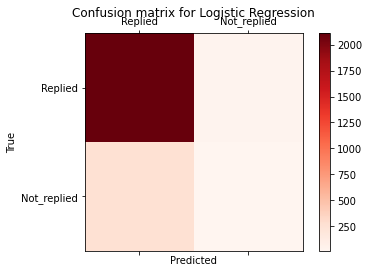

```python
%matplotlib inline

# Confusion matrix, accuracy, precison and recall for random forest and logistic regression
confusion_matrices = [
    ("Logistic Regression", confusion_matrix(model_test_y, best_RF_model.predict(model_test_x))),
    #("Logistic Regression", confusion_matrix(yc_test,best_LR_model.predict(Xc_test))),
]

draw_confusion_matrices(confusion_matrices)
```

#### ROC & AUC

```python
from sklearn.metrics import roc_curve
from sklearn import metrics

# Use predict_proba to get the probability results of Random Forest
y_pred_rf = best_RF_model.predict_proba(model_test_x)[:, 1]
fpr_rf, tpr_rf, _ = roc_curve(model_test_y, y_pred_rf)
```

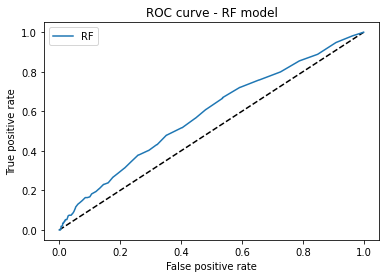

```python
# ROC curve of Random Forest result
plt.figure(1)
plt.plot([0, 1], [0, 1], 'k--')
plt.plot(fpr_rf, tpr_rf, label='RF')
plt.xlabel('False positive rate')
plt.ylabel('True positive rate')
plt.title('ROC curve - RF model')
plt.legend(loc='best')
plt.show()
```

```python
from sklearn import metrics

# AUC score
metrics.auc(fpr_rf,tpr_rf)
```

```
0.5850796551628475
```

### Feature selection

```python
# check feature importance of random forest for feature selection
forest = best_RF_model
forest.fit(model_train_x, model_train_y)

importances = forest.feature_importances_

# Print the feature ranking
print("Feature importance ranking by Random Forest Model:")
for k,v in sorted(zip(map(lambda x: round(x, 4), importances), model_train_x.columns), reverse=True):
    print (v + ": " + str(k))
```

```
Feature importance ranking by Random Forest Model:
message_length: 0.3048
lead_time: 0.2938
days_of_stay: 0.1639
total_reviews: 0.1025
guest_size: 0.0965
past_booker: 0.0238
contact_me: 0.0147
```

```
<sklearn.inspection._partial_dependence.PartialDependenceDisplay at 0x7f0342842dd8>
```

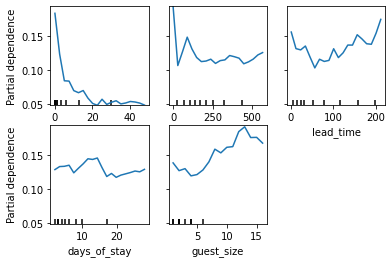

```python
from sklearn.inspection import plot_partial_dependence

features = ['total_reviews', 'message_length', 'lead_time', 'days_of_stay', 'guest_size']
plot_partial_dependence(best_RF_model, model_train_x, features,
                        n_jobs=4, grid_resolution=20)
```

## Logistic regression (numerical)

```python
# Check what features are included
all_inquiries = all_inquiries_df.copy()
all_inquiries = all_inquiries.drop(columns=['Unnamed: 0'])

all_inquiries.info()
```

```
<class 'pandas.core.frame.DataFrame'>
RangeIndex: 16083 entries, 0 to 16082
Data columns (total 9 columns):
 #   Column          Non-Null Count  Dtype
---  ------          --------------  -----
 0   guest_size      16083 non-null  float64
 1   message_length  16083 non-null  float64
 2   total_reviews   16083 non-null  float64
 3   lead_time       16083 non-null  int64
 4   days_of_stay    16083 non-null  int64
 5   replied         16083 non-null  int64
 6   not_replied     16083 non-null  int64
 7   contact_me      16083 non-null  int64
 8   past_booker     16083 non-null  int64
dtypes: float64(3), int64(6)
memory usage: 1.1 MB
```

### Feature Preprocessing

#### Interaction features

```python
all_inquiries['contact_me*past_booker'] = all_inquiries['contact_me'] * all_inquiries['past_booker']
all_inquiries['contact_me*lead_time'] = all_inquiries['contact_me'] * all_inquiries['lead_time']
all_inquiries['contact_me*guest size'] = all_inquiries['contact_me'] * all_inquiries['guest_size']

all_inquiries['message_length*lead_time'] = all_inquiries['message_length'] * all_inquiries['lead_time']
all_inquiries['message_length*days_of_stay'] = all_inquiries['message_length'] * all_inquiries['days_of_stay']

all_inquiries.info()
```

```
<class 'pandas.core.frame.DataFrame'>
RangeIndex: 16083 entries, 0 to 16082
Data columns (total 14 columns):
 #   Column                       Non-Null Count  Dtype
---  ------                       --------------  -----
 0   guest_size                   16083 non-null  float64
 1   message_length               16083 non-null  float64
 2   total_reviews                16083 non-null  float64
 3   lead_time                    16083 non-null  int64
 4   days_of_stay                 16083 non-null  int64
 5   replied                      16083 non-null  int64
 6   not_replied                  16083 non-null  int64
 7   contact_me                   16083 non-null  int64
 8   past_booker                  16083 non-null  int64
 9   contact_me*past_booker       16083 non-null  int64
 10  contact_me*lead_time         16083 non-null  int64
 11  contact_me*guest size        16083 non-null  float64
 12  message_length*lead_time     16083 non-null  float64
 13  message_length*days_of_stay  16083 non-null  float64
dtypes: float64(6), int64(8)
memory usage: 1.7 MB
```

#### Feature scaling

```python
# scale all features but categorical ones
from sklearn import preprocessing

scale_list = list(all_inquiries.columns)
scale_list.remove('replied')
scale_list.remove('not_replied')
scale_list.remove('contact_me')
scale_list.remove('past_booker')

# MinMax scaling
sc_scale = preprocessing.MinMaxScaler().fit(all_inquiries[scale_list])
all_inquiries[scale_list] = sc_scale.transform(all_inquiries[scale_list])
```

```python
all_inquiries.head(10)
```

|  | guest_size | message_length | total_reviews | lead_time | days_of_stay | replied | not_replied | contact_me | past_booker | contact_me*past_booker | contact_me*lead_time | contact_me*guest size | message_length*lead_time | message_length*days_of_stay |
| --- | --- | --- | --- | --- | --- | --- | --- | --- | --- | --- | --- | --- | --- | --- |
| 0 | 0.267 | 0.160 | 0.000 | 0.267 | 0.027 | 1 | 0 | 1 | 1 | 1.000 | 0.267 | 0.312 | 0.137 | 0.016 |
| 1 | 0.000 | 0.084 | 0.183 | 0.070 | 0.022 | 1 | 0 | 1 | 0 | 0.000 | 0.070 | 0.062 | 0.019 | 0.007 |
| 2 | 0.000 | 0.179 | 0.000 | 0.009 | 0.011 | 1 | 0 | 1 | 0 | 0.000 | 0.009 | 0.062 | 0.005 | 0.008 |
| 3 | 0.333 | 0.015 | 0.000 | 0.102 | 0.019 | 1 | 0 | 1 | 1 | 1.000 | 0.102 | 0.375 | 0.005 | 0.001 |
| 4 | 0.200 | 0.066 | 0.011 | 0.162 | 0.011 | 1 | 0 | 0 | 0 | 0.000 | 0.000 | 0.000 | 0.034 | 0.003 |
| 5 | 0.200 | 0.066 | 0.011 | 0.039 | 0.005 | 1 | 0 | 1 | 0 | 0.000 | 0.039 | 0.250 | 0.008 | 0.002 |
| 6 | 0.200 | 0.144 | 0.000 | 0.108 | 0.011 | 1 | 0 | 0 | 0 | 0.000 | 0.000 | 0.000 | 0.050 | 0.006 |
| 7 | 0.133 | 0.085 | 0.045 | 0.165 | 0.038 | 1 | 0 | 0 | 0 | 0.000 | 0.000 | 0.000 | 0.045 | 0.011 |
| 8 | 0.000 | 0.203 | 0.034 | 0.061 | 0.245 | 1 | 0 | 0 | 1 | 0.000 | 0.000 | 0.000 | 0.039 | 0.161 |
| 9 | 0.133 | 0.101 | 0.000 | 0.323 | 0.025 | 0 | 1 | 0 | 0 | 0.000 | 0.000 | 0.000 | 0.104 | 0.009 |

#### Split training and test data

```python
from sklearn.model_selection import train_test_split

# Not_replied is the positive behavior that we are observing
model_train, model_test = train_test_split(all_inquiries, test_size=0.15, random_state = 3)
model_train_x = model_train.drop(['replied', 'not_replied'], axis = 1)
model_test_x = model_test.drop(['replied', 'not_replied'], axis = 1)
model_train_y = model_train['not_replied']
model_test_y = model_test['not_replied']
```

### Train model and find optimal hypermarameters

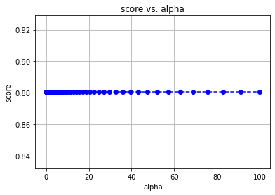

```
The optimaized alpha and score of Ridge linear is: 0.01 ,0.8805460750853242
```

```python
from sklearn.model_selection import train_test_split
from sklearn.linear_model import LogisticRegression
from sklearn.metrics import mean_squared_error, r2_score
from math import sqrt

lr_train, lr_validate = train_test_split(model_train, test_size=0.15, random_state = 0)

lr_train_x = lr_train.drop(['replied', 'not_replied'], axis = 1)
lr_validate_x = lr_validate.drop(['replied', 'not_replied'], axis = 1)
lr_train_y = lr_train['not_replied']
lr_validate_y = lr_validate['not_replied']

alphas = np.logspace (-2, 2, num=100)
# alphas= [1, 5, 10]
scores = np.empty_like(alphas)
opt_a = float('-inf')
max_score = float('-inf')
for i, a in enumerate(alphas):
    lasso = LogisticRegression(penalty='l2', C=a, solver='liblinear')
    lasso.fit(lr_train_x, lr_train_y)
    scores[i] = lasso.score(lr_validate_x, lr_validate_y)
    if scores[i] > max_score:
        max_score = scores[i]
        opt_a = a
        lasso_save = lasso
plt.plot(alphas, scores, color='b', linestyle='dashed', marker='o',markerfacecolor='blue', markersize=6)
plt.xlabel('alpha')
plt.ylabel('score')
plt.grid(True)
plt.title('score vs. alpha')
plt.show()
print('The optimaized alpha and score of Ridge linear is: ' + str(opt_a) + " ," + str(max_score))
```

```python
# combine the validate data and training data, use the optimal alpha, re-train the model
best_LR_model = LogisticRegression(penalty='l2', C=opt_a, solver='liblinear')
best_LR_model.fit(model_train_x, model_train_y)
```

```
LogisticRegression(C=0.01, class_weight=None, dual=False, fit_intercept=True,
                   intercept_scaling=1, l1_ratio=None, max_iter=100,
                   multi_class='auto', n_jobs=None, penalty='l2',
                   random_state=None, solver='liblinear', tol=0.0001, verbose=0,
                   warm_start=False)
```

### Model evaluation

#### Confusion matrix

```python
from sklearn.metrics import confusion_matrix
from sklearn.metrics import classification_report
from sklearn.metrics import precision_score
from sklearn.metrics import recall_score

# calculate accuracy, precision and recall, [[tn, fp],[]]
def cal_evaluation(classifier, cm):
    tn = cm[0][0]
    fp = cm[0][1]
    fn = cm[1][0]
    tp = cm[1][1]
    accuracy  = (tp + tn) / (tp + fp + fn + tn + 0.0)
    precision = tp / (tp + fp + 0.0)
    recall = tp / (tp + fn + 0.0)
    print (classifier)
    print ("Accuracy is: %0.3f" % accuracy)
    print ("precision is: %0.3f" % precision)
    print ("recall is: %0.3f" % recall)

# print out confusion matrices
def draw_confusion_matrices(confusion_matricies):
    class_names = ['Replied','Not_replied']
    for cm in confusion_matrices:
        classifier, cm = cm[0], cm[1]
        cal_evaluation(classifier, cm)
        fig = plt.figure()
        ax = fig.add_subplot(111)
        cax = ax.matshow(cm, interpolation='nearest',cmap=plt.get_cmap('Reds'))
        plt.title('Confusion matrix for %s' % classifier)
        fig.colorbar(cax)
        ax.set_xticklabels([''] + class_names)
        ax.set_yticklabels([''] + class_names)
        plt.xlabel('Predicted')
        plt.ylabel('True')
        plt.show()
```

```python
confusion_matrix(model_test_y, best_LR_model.predict(model_test_x))
```

```
array([[2144,    0],
       [ 269,    0]])
```

```
Logistic Regression
Accuracy is: 0.889
precision is: nan
recall is: 0.000
```

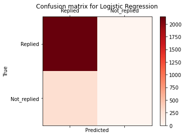

```python
%matplotlib inline

# Confusion matrix, accuracy, precison and recall for random forest and logistic regression
confusion_matrices = [
    ("Logistic Regression", confusion_matrix(model_test_y, best_LR_model.predict(model_test_x))),
]

draw_confusion_matrices(confusion_matrices)
```

#### ROC & AUC

```python
from sklearn.metrics import roc_curve
from sklearn import metrics

# Use predict_proba to get the probability results of Logistic Regression
y_pred_lr = best_LR_model.predict_proba(model_test_x)[:, 1]
fpr_lr, tpr_lr, _ = roc_curve(model_test_y, y_pred_lr)
```

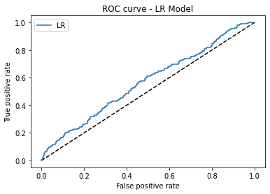

```python
# ROC Curve
plt.figure(1)
plt.plot([0, 1], [0, 1], 'k--')
plt.plot(fpr_lr, tpr_lr, label='LR')
plt.xlabel('False positive rate')
plt.ylabel('True positive rate')
plt.title('ROC curve - LR Model')
plt.legend(loc='best')
plt.show()
```

```python
# AUC score
metrics.auc(fpr_lr,tpr_lr)
```

```
0.5672092603895023
```

### Feature selection

```python
# Store the coef for feature selection
res = pd.DataFrame(columns=['Feature', 'Coef'])

for k,v in sorted(zip(map(lambda x: round(x, 4), best_LR_model.fit(model_train_x, model_train_y).coef_[0]), \
                      model_train_x.columns), key=lambda k_v:(-abs(k_v[0]),k_v[1])):
    print (v + ": " + str(k))
    res = res.append({'Feature': v, 'Coef': k}, ignore_index=True)
```

```
contact_me: -0.4615
total_reviews: -0.3843
message_length: -0.2695
past_booker: -0.2208
contact_me*past_booker: 0.143
guest_size: -0.0956
contact_me*lead_time: 0.0635
message_length*lead_time: -0.0317
days_of_stay: -0.026
message_length*days_of_stay: -0.0223
contact_me*guest size: -0.0183
lead_time: -0.0047
```

## Logistic regression (binned numerical)

```python
# Check what features are included
all_inquiries = all_inquiries_df.copy()
all_inquiries = all_inquiries.drop(columns=['Unnamed: 0'])

all_inquiries.info()
```

```
<class 'pandas.core.frame.DataFrame'>
RangeIndex: 16083 entries, 0 to 16082
Data columns (total 9 columns):
 #   Column          Non-Null Count  Dtype
---  ------          --------------  -----
 0   guest_size      16083 non-null  float64
 1   message_length  16083 non-null  float64
 2   total_reviews   16083 non-null  float64
 3   lead_time       16083 non-null  int64
 4   days_of_stay    16083 non-null  int64
 5   replied         16083 non-null  int64
 6   not_replied     16083 non-null  int64
 7   contact_me      16083 non-null  int64
 8   past_booker     16083 non-null  int64
dtypes: float64(3), int64(6)
memory usage: 1.1 MB
```

### Feature Preprocessing

#### Feature encoding

In order to see the nuances of some features' impact, I decided to create buckets for numerical variables including:

- Review
- Lead time
- Days of stay
- Message length
- Guest size

```python
# Binning reviews
review = [-1,0,10,20,30,1000]
review_range = ['0','1-10','11-20','21-30','>30']
reviews_bin = pd.cut(all_inquiries['total_reviews'], bins = review, labels=review_range)
all_inquiries['reviews'] = reviews_bin

# Binning lead time
lead = [-1,30,60,90,1000]
lead_range = ['1-30d','31-60d','61-90d', '>90d']
lead_bin = pd.cut(all_inquiries['lead_time'], bins = lead, labels=lead_range)
all_inquiries['lead_time'] = lead_bin

# Binning days_of_stay
stay = [-1,5,10,15,1000]
stay_range = ['1-5d','6-10d','11-15d','>15d']
stay_bin = pd.cut(all_inquiries['days_of_stay'], bins = stay, labels=stay_range)
all_inquiries['days_of_stay'] = stay_bin

# Binning message_length
length = [-1,150,300,450,3000]
length_range = ['0-150','151-300','301-450','>450']
length_bin = pd.cut(all_inquiries['message_length'], bins = length, labels=length_range)
all_inquiries['message_length'] = length_bin

# Binning guest size
size = [-1,1,2,4,6,30]
size_range = ['1','2','3-4','5-6','>6']
size_bin = pd.cut(all_inquiries['guest_size'], bins = size, labels=size_range)
all_inquiries['guest_size'] = size_bin
```

```python
# generate binary values using get_dummies
all_inquiries = pd.get_dummies(all_inquiries, columns=["reviews", "lead_time", "days_of_stay", "message_length", "guest_size"] )
```

```python
# Drop columns not to be used
all_inquiries = all_inquiries.drop(['total_reviews'], axis = 1)
```

```python
all_inquiries.info()
```

```
<class 'pandas.core.frame.DataFrame'>
RangeIndex: 16083 entries, 0 to 16082
Data columns (total 26 columns):
 #   Column                  Non-Null Count  Dtype
---  ------                  --------------  -----
 0   replied                 16083 non-null  int64
 1   not_replied             16083 non-null  int64
 2   contact_me              16083 non-null  int64
 3   past_booker             16083 non-null  int64
 4   reviews_0               16083 non-null  uint8
 5   reviews_1-10            16083 non-null  uint8
 6   reviews_11-20           16083 non-null  uint8
 7   reviews_21-30           16083 non-null  uint8
 8   reviews_>30             16083 non-null  uint8
 9   lead_time_1-30d         16083 non-null  uint8
```

[output cut: 18 more lines]

#### Interaction features

Creat interaction features to discover combined effects of independent variables

```python
# Interaction features

reviews = all_inquiries.columns[4:9]
lead_times = all_inquiries.columns[9:13]
stays = all_inquiries.columns[13:17]
message_lengths = all_inquiries.columns[17:21]
guest_sizes = all_inquiries.columns[21:26]

# Channel * user stage
all_inquiries['contact_me*past_booker'] = all_inquiries['contact_me'] * all_inquiries['past_booker']

# Channel * lead_time
for i in lead_times:
  all_inquiries['contact_me'+'*'+i] = all_inquiries['contact_me'] * all_inquiries[i]

# Channel * guest size
for i in guest_sizes:
  all_inquiries['contact_me'+'*'+i] = all_inquiries['contact_me'] * all_inquiries[i]

# Message length * days of stay
for i in message_lengths:
  for j in stays:
    all_inquiries[i+'*'+j] = all_inquiries[i] * all_inquiries[j]

# Message length * lead time
for i in message_lengths:
  for j in lead_times:
    all_inquiries[i+'*'+j] = all_inquiries[i] * all_inquiries[j]
```

```python
all_inquiries.info()
```

```
<class 'pandas.core.frame.DataFrame'>
RangeIndex: 16083 entries, 0 to 16082
Data columns (total 68 columns):
 #   Column                                      Non-Null Count  Dtype
---  ------                                      --------------  -----
 0   replied                                     16083 non-null  int64
 1   not_replied                                 16083 non-null  int64
 2   contact_me                                  16083 non-null  int64
 3   past_booker                                 16083 non-null  int64
 4   reviews_0                                   16083 non-null  uint8
 5   reviews_1-10                                16083 non-null  uint8
 6   reviews_11-20                               16083 non-null  uint8
 7   reviews_21-30                               16083 non-null  uint8
 8   reviews_>30                                 16083 non-null  uint8
 9   lead_time_1-30d                             16083 non-null  uint8
```

[output cut: 60 more lines]

#### Split training and test data

```python
# Split training and test dataset
from sklearn.model_selection import train_test_split

# Not_replied is the positive behavior that we are observing
model_train, model_test = train_test_split(all_inquiries, test_size=0.15, random_state = 3)
model_train_x = model_train.drop(['replied', 'not_replied'], axis = 1)
model_test_x = model_test.drop(['replied', 'not_replied'], axis = 1)
model_train_y = model_train['not_replied']
model_test_y = model_test['not_replied']
```

### Train model and find optimal hypermarameters

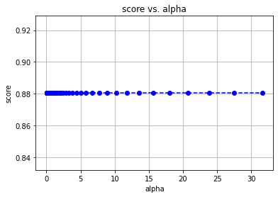

[output not shown]

```python
from sklearn.model_selection import train_test_split
from sklearn.linear_model import LogisticRegression
from sklearn.metrics import mean_squared_error, r2_score
from math import sqrt

lr_train, lr_validate = train_test_split(model_train, test_size=0.15, random_state = 0)

lr_train_x = lr_train.drop(['replied', 'not_replied'], axis = 1)
lr_validate_x = lr_validate.drop(['replied', 'not_replied'], axis = 1)
lr_train_y = lr_train['not_replied']
lr_validate_y = lr_validate['not_replied']

alphas = np.logspace (-1.5, 1.5, num=50)
# alphas= [1, 5, 10]
scores = np.empty_like(alphas)
opt_a = float('-inf')
max_score = float('-inf')
for i, a in enumerate(alphas):
    lasso = LogisticRegression(penalty='l1', C=a, solver='liblinear')
    lasso.fit(lr_train_x, lr_train_y)
    scores[i] = lasso.score(lr_validate_x, lr_validate_y)
    if scores[i] > max_score:
        max_score = scores[i]
        opt_a = a
        lasso_save = lasso
plt.plot(alphas, scores, color='b', linestyle='dashed', marker='o',markerfacecolor='blue', markersize=6)
plt.xlabel('alpha')
plt.ylabel('score')
plt.grid(True)
plt.title('score vs. alpha')
plt.show()
print('The optimaized alpha and score of Lasso linear is: ' + str(opt_a) + " ," + str(max_score))
```

```python
# combine the validate data and training data, use the optimal alpha, re-train the model
best_LR_model = LogisticRegression(penalty='l1', C=opt_a, solver='liblinear')
best_LR_model.fit(model_train_x, model_train_y)
```

```
LogisticRegression(C=0.03162277660168379, class_weight=None, dual=False,
                   fit_intercept=True, intercept_scaling=1, l1_ratio=None,
                   max_iter=100, multi_class='auto', n_jobs=None, penalty='l1',
                   random_state=None, solver='liblinear', tol=0.0001, verbose=0,
                   warm_start=False)
```

### Model evaluation

#### Confusion matrix

```python
from sklearn.metrics import confusion_matrix
from sklearn.metrics import classification_report
from sklearn.metrics import precision_score
from sklearn.metrics import recall_score

# calculate accuracy, precision and recall, [[tn, fp],[]]
def cal_evaluation(classifier, cm):
    tn = cm[0][0]
    fp = cm[0][1]
    fn = cm[1][0]
    tp = cm[1][1]
    accuracy  = (tp + tn) / (tp + fp + fn + tn + 0.0)
    precision = tp / (tp + fp + 0.0)
    recall = tp / (tp + fn + 0.0)
    print (classifier)
    print ("Accuracy is: %0.3f" % accuracy)
    print ("precision is: %0.3f" % precision)
    print ("recall is: %0.3f" % recall)

# print out confusion matrices
def draw_confusion_matrices(confusion_matricies):
    class_names = ['Replied','Not_Replied']
    for cm in confusion_matrices:
        classifier, cm = cm[0], cm[1]
        cal_evaluation(classifier, cm)
        fig = plt.figure()
        ax = fig.add_subplot(111)
        cax = ax.matshow(cm, interpolation='nearest',cmap=plt.get_cmap('Reds'))
        plt.title('Confusion matrix for %s' % classifier)
        fig.colorbar(cax)
        ax.set_xticklabels([''] + class_names)
        ax.set_yticklabels([''] + class_names)
        plt.xlabel('Predicted')
        plt.ylabel('True')
        plt.show()
```

```python
confusion_matrix(model_test_y, best_LR_model.predict(model_test_x))
```

```
array([[2144,    0],
       [ 269,    0]])
```

```
Logistic Regression
Accuracy is: 0.889
precision is: nan
recall is: 0.000
```

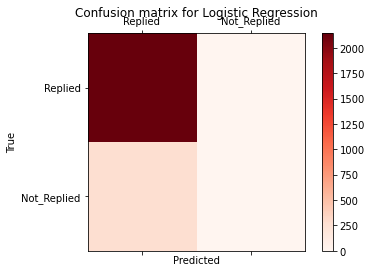

```python
%matplotlib inline

# Confusion matrix, accuracy, precison and recall for random forest and logistic regression
confusion_matrices = [
    ("Logistic Regression", confusion_matrix(model_test_y, best_LR_model.predict(model_test_x))),
    #("Logistic Regression", confusion_matrix(yc_test,best_LR_model.predict(Xc_test))),
]

draw_confusion_matrices(confusion_matrices)
```

#### ROC & AUC

```python
from sklearn.metrics import roc_curve
from sklearn import metrics

# Use predict_proba to get the probability results of Logistic Regression
y_pred_lr = best_LR_model.predict_proba(model_test_x)[:, 1]
fpr_lr, tpr_lr, _ = roc_curve(model_test_y, y_pred_lr)
```

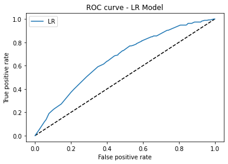

```python
# ROC Curve
plt.figure(1)
plt.plot([0, 1], [0, 1], 'k--')
plt.plot(fpr_lr, tpr_lr, label='LR')
plt.xlabel('False positive rate')
plt.ylabel('True positive rate')
plt.title('ROC curve - LR Model')
plt.legend(loc='best')
plt.show()
```

```python
# AUC score
metrics.auc(fpr_lr,tpr_lr)
```

```
0.6603966112744827
```

### Feature selection

```python
# Store the coef for feature selection
res = pd.DataFrame(columns=['Feature', 'Coef'])

for k,v in sorted(zip(map(lambda x: round(x, 4), best_LR_model.fit(model_train_x, model_train_y).coef_[0]), \
                      model_train_x.columns), key=lambda k_v:(-abs(k_v[0]),k_v[1])):
    print (v + ": " + str(k))
    res = res.append({'Feature': v, 'Coef': k}, ignore_index=True)
```

```
reviews_0: 0.5532
reviews_>30: -0.5313
contact_me: -0.3063
reviews_11-20: -0.2067
message_length_0-150: 0.1175
lead_time_>90d: 0.0576
lead_time_31-60d: -0.0113
reviews_21-30: -0.0072
contact_me*guest_size_1: 0.0
contact_me*guest_size_2: 0.0
contact_me*guest_size_3-4: 0.0
contact_me*guest_size_5-6: 0.0
contact_me*guest_size_>6: 0.0
contact_me*lead_time_1-30d: 0.0
contact_me*lead_time_31-60d: 0.0
contact_me*lead_time_61-90d: 0.0
contact_me*lead_time_>90d: 0.0
contact_me*past_booker: 0.0
days_of_stay_1-5d: 0.0
days_of_stay_11-15d: 0.0
days_of_stay_6-10d: 0.0
days_of_stay_>15d: 0.0
guest_size_1: 0.0
guest_size_2: 0.0
guest_size_3-4: 0.0
guest_size_5-6: 0.0
guest_size_>6: 0.0
lead_time_1-30d: 0.0
lead_time_61-90d: 0.0
message_length_0-150*days_of_stay_1-5d: 0.0
message_length_0-150*days_of_stay_11-15d: 0.0
message_length_0-150*days_of_stay_6-10d: 0.0
message_length_0-150*days_of_stay_>15d: 0.0
message_length_0-150*lead_time_1-30d: 0.0
message_length_0-150*lead_time_31-60d: 0.0
message_length_0-150*lead_time_61-90d: 0.0
message_length_0-150*lead_time_>90d: 0.0
message_length_151-300: 0.0
message_length_151-300*days_of_stay_1-5d: 0.0
message_length_151-300*days_of_stay_11-15d: 0.0
```

[output cut: 11 more lines]

```
message_length_301-450*lead_time_1-30d: 0.0
message_length_301-450*lead_time_31-60d: 0.0
message_length_301-450*lead_time_61-90d: 0.0
message_length_301-450*lead_time_>90d: 0.0
message_length_>450: 0.0
message_length_>450*days_of_stay_1-5d: 0.0
message_length_>450*days_of_stay_11-15d: 0.0
message_length_>450*days_of_stay_6-10d: 0.0
message_length_>450*days_of_stay_>15d: 0.0
message_length_>450*lead_time_1-30d: 0.0
message_length_>450*lead_time_31-60d: 0.0
message_length_>450*lead_time_61-90d: 0.0
message_length_>450*lead_time_>90d: 0.0
past_booker: 0.0
reviews_1-10: 0.0
```

## Final model

And logistic regression model with binned numerical features have the best performance(AUC score: 0.66) .

```python
# Check what features are included
all_inquiries = all_inquiries_df.copy()
all_inquiries = all_inquiries[['not_replied', 'message_length', 'total_reviews', 'contact_me', 'lead_time']]

all_inquiries.info()
```

```
<class 'pandas.core.frame.DataFrame'>
RangeIndex: 16083 entries, 0 to 16082
Data columns (total 5 columns):
 #   Column          Non-Null Count  Dtype
---  ------          --------------  -----
 0   not_replied     16083 non-null  int64
 1   message_length  16083 non-null  float64
 2   total_reviews   16083 non-null  float64
 3   contact_me      16083 non-null  int64
 4   lead_time       16083 non-null  int64
dtypes: float64(2), int64(3)
memory usage: 628.4 KB
```

#### Feature encoding

```python
# Binning reviews
review = [-1,0,10,20,30,1000]
review_range = ['0','1-10','11-20','21-30','>30']
reviews_bin = pd.cut(all_inquiries['total_reviews'], bins = review, labels=review_range)
all_inquiries['reviews'] = reviews_bin
all_inquiries = all_inquiries.drop(columns=['total_reviews'])

# Binning message_length
length = [-1,150,300,450,3000]
length_range = ['0-150','151-300','301-450','>450']
length_bin = pd.cut(all_inquiries['message_length'], bins = length, labels=length_range)
all_inquiries['message_length'] = length_bin

# Binning lead time
lead = [-1,30,60,90,1000]
lead_range = ['1-30d','31-60d','61-90d', '>90d']
lead_bin = pd.cut(all_inquiries['lead_time'], bins = lead, labels=lead_range)
all_inquiries['lead_time'] = lead_bin
```

```python
# generate binary values using get_dummies
all_inquiries = pd.get_dummies(all_inquiries, columns=["reviews", "message_length", "lead_time"] )

all_inquiries.info()
```

```
<class 'pandas.core.frame.DataFrame'>
RangeIndex: 16083 entries, 0 to 16082
Data columns (total 15 columns):
 #   Column                  Non-Null Count  Dtype
---  ------                  --------------  -----
 0   not_replied             16083 non-null  int64
 1   contact_me              16083 non-null  int64
 2   reviews_0               16083 non-null  uint8
 3   reviews_1-10            16083 non-null  uint8
 4   reviews_11-20           16083 non-null  uint8
 5   reviews_21-30           16083 non-null  uint8
 6   reviews_>30             16083 non-null  uint8
 7   message_length_0-150    16083 non-null  uint8
 8   message_length_151-300  16083 non-null  uint8
 9   message_length_301-450  16083 non-null  uint8
 10  message_length_>450     16083 non-null  uint8
 11  lead_time_1-30d         16083 non-null  uint8
 12  lead_time_31-60d        16083 non-null  uint8
 13  lead_time_61-90d        16083 non-null  uint8
 14  lead_time_>90d          16083 non-null  uint8
dtypes: int64(2), uint8(13)
memory usage: 455.6 KB
```

#### Split training and test data

```python
from sklearn.model_selection import train_test_split

# Not_replied is the positive behavior that we are observing
model_train, model_test = train_test_split(all_inquiries, test_size=0.15, random_state = 3)
model_train_x = model_train.drop(['not_replied'], axis = 1)
model_test_x = model_test.drop(['not_replied'], axis = 1)
model_train_y = model_train['not_replied']
model_test_y = model_test['not_replied']
```

### Train model and find optimal hypermarameters

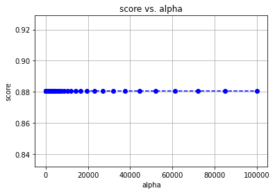

```
The optimaized alpha and score of Lasso linear is: 0.01 ,0.8805460750853242
```

```python
from sklearn.model_selection import train_test_split
from sklearn.linear_model import LogisticRegression
from sklearn.metrics import mean_squared_error, r2_score
from math import sqrt

lr_train, lr_validate = train_test_split(model_train, test_size=0.15, random_state = 0)

lr_train_x = lr_train.drop(['not_replied'], axis = 1)
lr_validate_x = lr_validate.drop(['not_replied'], axis = 1)
lr_train_y = lr_train['not_replied']
lr_validate_y = lr_validate['not_replied']

alphas = np.logspace (-2, 5, num=100)
# alphas= [1, 5, 10]
scores = np.empty_like(alphas)
opt_a = float('-inf')
max_score = float('-inf')
for i, a in enumerate(alphas):
    lasso = LogisticRegression(penalty='l2', C=a, solver='liblinear')
    lasso.fit(lr_train_x, lr_train_y)
    scores[i] = lasso.score(lr_validate_x, lr_validate_y)
    if scores[i] > max_score:
        max_score = scores[i]
        opt_a = a
        lasso_save = lasso
plt.plot(alphas, scores, color='b', linestyle='dashed', marker='o',markerfacecolor='blue', markersize=6)
plt.xlabel('alpha')
plt.ylabel('score')
plt.grid(True)
plt.title('score vs. alpha')
plt.show()
print('The optimaized alpha and score of Lasso linear is: ' + str(opt_a) + " ," + str(max_score))
```

```python
# combine the validate data and training data, use the optimal alpha, re-train the model
best_LR_model = LogisticRegression(penalty='l2', C=opt_a, solver='liblinear')
best_LR_model.fit(model_train_x, model_train_y)
```

```
LogisticRegression(C=0.01, class_weight=None, dual=False, fit_intercept=True,
                   intercept_scaling=1, l1_ratio=None, max_iter=100,
                   multi_class='auto', n_jobs=None, penalty='l2',
                   random_state=None, solver='liblinear', tol=0.0001, verbose=0,
                   warm_start=False)
```

### Model evaluation

#### Confusion matrix

```python
from sklearn.metrics import confusion_matrix
from sklearn.metrics import classification_report
from sklearn.metrics import precision_score
from sklearn.metrics import recall_score

# calculate accuracy, precision and recall, [[tn, fp],[]]
def cal_evaluation(classifier, cm):
    tn = cm[0][0]
    fp = cm[0][1]
    fn = cm[1][0]
    tp = cm[1][1]
    accuracy  = (tp + tn) / (tp + fp + fn + tn + 0.0)
    precision = tp / (tp + fp + 0.0)
    recall = tp / (tp + fn + 0.0)
    print (classifier)
    print ("Accuracy is: %0.3f" % accuracy)
    print ("precision is: %0.3f" % precision)
    print ("recall is: %0.3f" % recall)

# print out confusion matrices
def draw_confusion_matrices(confusion_matricies):
    class_names = ['Replied','Not_Replied']
    for cm in confusion_matrices:
        classifier, cm = cm[0], cm[1]
        cal_evaluation(classifier, cm)
        fig = plt.figure()
        ax = fig.add_subplot(111)
        cax = ax.matshow(cm, interpolation='nearest',cmap=plt.get_cmap('Reds'))
        plt.title('Confusion matrix for %s' % classifier)
        fig.colorbar(cax)
        ax.set_xticklabels([''] + class_names)
        ax.set_yticklabels([''] + class_names)
        plt.xlabel('Predicted')
        plt.ylabel('True')
        plt.show()
```

```python
confusion_matrix(model_test_y, best_LR_model.predict(model_test_x))
```

```
array([[2144,    0],
       [ 269,    0]])
```

```
Logistic Regression
Accuracy is: 0.889
precision is: nan
recall is: 0.000
```

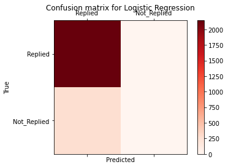

```python
%matplotlib inline

# Confusion matrix, accuracy, precison and recall for random forest and logistic regression
confusion_matrices = [
    ("Logistic Regression", confusion_matrix(model_test_y, best_LR_model.predict(model_test_x))),
    #("Logistic Regression", confusion_matrix(yc_test,best_LR_model.predict(Xc_test))),
]

draw_confusion_matrices(confusion_matrices)
```

#### ROC & AUC

```python
from sklearn.metrics import roc_curve
from sklearn import metrics

# Use predict_proba to get the probability results of Logistic Regression
y_pred_lr = best_LR_model.predict_proba(model_test_x)[:, 1]
fpr_lr, tpr_lr, _ = roc_curve(model_test_y, y_pred_lr)
```

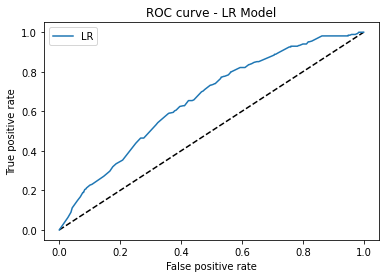

```python
# ROC Curve
plt.figure(1)
plt.plot([0, 1], [0, 1], 'k--')
plt.plot(fpr_lr, tpr_lr, label='LR')
plt.xlabel('False positive rate')
plt.ylabel('True positive rate')
plt.title('ROC curve - LR Model')
plt.legend(loc='best')
plt.show()
```

```python
# AUC score
metrics.auc(fpr_lr,tpr_lr)
```

```
0.6578625228874216
```

### Results interpretation

```python
# Store the coef for results interpretation
res = pd.DataFrame(columns=['Feature', 'Coef'])

for k,v in sorted(zip(map(lambda x: round(x, 4), best_LR_model.fit(model_train_x, model_train_y).coef_[0]), \
                      model_train_x.columns), key=lambda k_v:(-abs(k_v[0]),k_v[1])):
    print (v + ": " + str(k))
    res = res.append({'Feature': v, 'Coef': k}, ignore_index=True)
```

```
reviews_>30: -0.5439
contact_me: -0.4002
reviews_11-20: -0.3974
message_length_151-300: -0.3467
lead_time_31-60d: -0.334
lead_time_1-30d: -0.3076
reviews_21-30: -0.301
message_length_301-450: -0.2999
reviews_0: 0.2982
lead_time_61-90d: -0.2833
message_length_>450: -0.2778
message_length_0-150: -0.1837
lead_time_>90d: -0.1832
reviews_1-10: -0.1639
```

```python
reviews = all_inquiries.columns[2:7]
message_lengths = all_inquiries.columns[7:11]
lead_times = all_inquiries.columns[11:15]

res = res.set_index('Feature')

print('contact_me: ' + str(res.Coef.loc['contact_me']))

for i in list(reviews):
  print(i + ": " + str(res.Coef.loc[i]))

for i in list(message_lengths):
  print(i + ": " + str(res.Coef.loc[i]))

for i in list(lead_times):
  print(i + ": " + str(res.Coef.loc[i]))
```

```
contact_me: -0.4002
reviews_0: 0.2982
reviews_1-10: -0.1639
reviews_11-20: -0.3974
reviews_21-30: -0.301
reviews_>30: -0.5439
message_length_0-150: -0.1837
message_length_151-300: -0.3467
message_length_301-450: -0.2999
message_length_>450: -0.2778
lead_time_1-30d: -0.3076
lead_time_31-60d: -0.334
lead_time_61-90d: -0.2833
lead_time_>90d: -0.1832
```

- Inquiries in contact me channel are more likely to be replied.
- 0 review is associated with non-replies.
- Messages with 151-300 characters are most likely to be replied, messages too short(0-150 characters) or too long(>450) both have a lower chance to be replied.

```python
from google.colab import files

res.to_csv('mod1_res.csv')
files.download('mod1_res.csv')
```

# Replied inquiries

The goal in this section is to find **what drives hosts' acceptance** for replied inquiries in Contact Me and Book It channel using ML models.

Inquiries where **reply timestamp equals accept timestamp** are **excluded**.

```python
# check the propotion of accepted = 1
y = replied_inquiries_df['accepted']
print(y.sum() / y.shape * 100)
```

```
[34.94231722]
```

The number of inquiries that were accepted is less than those weren't

## Random forest

```python
# Check what features are included
replied_inquiries = replied_inquiries_df.copy()
replied_inquiries = replied_inquiries.drop(columns=['Unnamed: 0'])

replied_inquiries.info()
```

```
<class 'pandas.core.frame.DataFrame'>
RangeIndex: 14129 entries, 0 to 14128
Data columns (total 10 columns):
 #   Column              Non-Null Count  Dtype
---  ------              --------------  -----
 0   guest_size          14129 non-null  float64
 1   total_interactions  14129 non-null  int64
 2   message_length      14129 non-null  float64
 3   total_reviews       14129 non-null  float64
 4   lead_time           14129 non-null  int64
 5   days_of_stay        14129 non-null  int64
 6   reply_t             14129 non-null  float64
 7   accepted            14129 non-null  int64
 8   contact_me          14129 non-null  int64
 9   past_booker         14129 non-null  int64
dtypes: float64(4), int64(6)
memory usage: 1.1 MB
```

#### Split training and test data

```python
from sklearn.model_selection import train_test_split

model_train, model_test = train_test_split(replied_inquiries, test_size=0.15, random_state = 3)
model_train_x = model_train.drop(['accepted'], axis = 1)
model_test_x = model_test.drop(['accepted'], axis = 1)
model_train_y = model_train['accepted']
model_test_y = model_test['accepted']
```

### Train model and find optimal hypermarameters

```python
from sklearn.model_selection import GridSearchCV

# helper function for printing out grid search results
def print_grid_search_metrics(gs):
    print ("Best score: %0.3f" % gs.best_score_)
    print ("Best parameters set:")
    best_parameters = gs.best_params_
    for param_name in sorted(parameters.keys()):
        print("\t%s: %r" % (param_name, best_parameters[param_name]))
```

```python
from sklearn.ensemble import RandomForestClassifier

# Possible hyperparamter options for Random Forest
# Choose the number of trees
parameters = {
    'n_estimators' : np.arange(65,75)
    #
}
Grid_RF = GridSearchCV(RandomForestClassifier(),parameters, cv=5)
Grid_RF.fit(model_train_x, model_train_y)
```

```
GridSearchCV(cv=5, error_score=nan,
             estimator=RandomForestClassifier(bootstrap=True, ccp_alpha=0.0,
                                              class_weight=None,
                                              criterion='gini', max_depth=None,
                                              max_features='auto',
                                              max_leaf_nodes=None,
                                              max_samples=None,
                                              min_impurity_decrease=0.0,
                                              min_impurity_split=None,
                                              min_samples_leaf=1,
                                              min_samples_split=2,
                                              min_weight_fraction_leaf=0.0,
                                              n_estimators=100, n_jobs=None,
                                              oob_score=False,
                                              random_state=None, verbose=0,
                                              warm_start=False),
             iid='deprecated', n_jobs=None,
             param_grid={'n_estimators': array([65, 66, 67, 68, 69, 70, 71, 72, 73, 74])},
             pre_dispatch='2*n_jobs', refit=True, return_train_score=False,
             scoring=None, verbose=0)
```

```python
# best number of tress
print_grid_search_metrics(Grid_RF)

# best random forest
best_RF_model = Grid_RF.best_estimator_
```

```
Best score: 0.788
Best parameters set:
	n_estimators: 68
```

### Model evaluation

#### Confusion matrix

```python
from sklearn.metrics import confusion_matrix
from sklearn.metrics import classification_report
from sklearn.metrics import precision_score
from sklearn.metrics import recall_score

# calculate accuracy, precision and recall, [[tn, fp],[]]
def cal_evaluation(classifier, cm):
    tn = cm[0][0]
    fp = cm[0][1]
    fn = cm[1][0]
    tp = cm[1][1]
    accuracy  = (tp + tn) / (tp + fp + fn + tn + 0.0)
    precision = tp / (tp + fp + 0.0)
    recall = tp / (tp + fn + 0.0)
    print (classifier)
    print ("Accuracy is: %0.3f" % accuracy)
    print ("precision is: %0.3f" % precision)
    print ("recall is: %0.3f" % recall)

# print out confusion matrices
def draw_confusion_matrices(confusion_matricies):
    class_names = ['Not_accepted','Accepted']
    for cm in confusion_matrices:
        classifier, cm = cm[0], cm[1]
        cal_evaluation(classifier, cm)
        fig = plt.figure()
        ax = fig.add_subplot(111)
        cax = ax.matshow(cm, interpolation='nearest',cmap=plt.get_cmap('Reds'))
        plt.title('Confusion matrix for %s' % classifier)
        fig.colorbar(cax)
        ax.set_xticklabels([''] + class_names)
        ax.set_yticklabels([''] + class_names)
        plt.xlabel('Predicted')
        plt.ylabel('True')
        plt.show()
```

```python
confusion_matrix(model_test_y, best_RF_model.predict(model_test_x))
```

```
array([[1193,  156],
       [ 309,  462]])
```

```
Logistic Regression
Accuracy is: 0.781
precision is: 0.748
recall is: 0.599
```

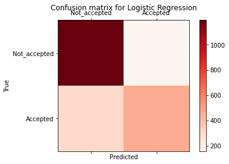

```python
%matplotlib inline

# Confusion matrix, accuracy, precison and recall for random forest and logistic regression
confusion_matrices = [
    ("Logistic Regression", confusion_matrix(model_test_y, best_RF_model.predict(model_test_x))),
    #("Logistic Regression", confusion_matrix(yc_test,best_LR_model.predict(Xc_test))),
]

draw_confusion_matrices(confusion_matrices)
```

#### ROC & AUC

```python
from sklearn.metrics import roc_curve
from sklearn import metrics

# Use predict_proba to get the probability results of Random Forest
y_pred_rf = best_RF_model.predict_proba(model_test_x)[:, 1]
fpr_rf, tpr_rf, _ = roc_curve(model_test_y, y_pred_rf)
```

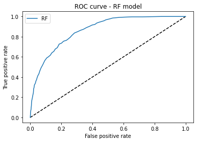

```python
# ROC curve of Random Forest result
plt.figure(1)
plt.plot([0, 1], [0, 1], 'k--')
plt.plot(fpr_rf, tpr_rf, label='RF')
plt.xlabel('False positive rate')
plt.ylabel('True positive rate')
plt.title('ROC curve - RF model')
plt.legend(loc='best')
plt.show()
```

```python
from sklearn import metrics

# AUC score
metrics.auc(fpr_rf,tpr_rf)
```

```
0.863602187910726
```

### Feature selection

```python
# check feature importance of random forest for feature selection
forest = best_RF_model
forest.fit(model_train_x, model_train_y)

importances = forest.feature_importances_

# Print the feature ranking
print("Feature importance ranking by Random Forest Model:")
for k,v in sorted(zip(map(lambda x: round(x, 4), importances), model_train_x.columns), reverse=True):
    print (v + ": " + str(k))
```

```
Feature importance ranking by Random Forest Model:
total_interactions: 0.328
reply_t: 0.1465
lead_time: 0.1236
message_length: 0.1182
total_reviews: 0.1046
days_of_stay: 0.083
guest_size: 0.0518
contact_me: 0.0269
past_booker: 0.0173
```

```
<sklearn.inspection._partial_dependence.PartialDependenceDisplay at 0x7f03428ca208>
```

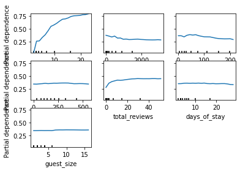

```python
from sklearn.inspection import plot_partial_dependence

features = ['total_interactions', 'reply_t', 'lead_time', 'message_length', 'total_reviews', 'days_of_stay', 'guest_size']
plot_partial_dependence(best_RF_model, model_train_x, features,
                        n_jobs=4, grid_resolution=20)
```

Interactions, reply_t, lead_time, message_length, and reviews are the most important features according to RF model results

## Logistic regression (numerical)

```python
# Check what features are included
replied_inquiries = replied_inquiries_df.copy()
replied_inquiries = replied_inquiries.drop(columns=['Unnamed: 0'])

replied_inquiries.info()
```

```
<class 'pandas.core.frame.DataFrame'>
RangeIndex: 14129 entries, 0 to 14128
Data columns (total 10 columns):
 #   Column              Non-Null Count  Dtype
---  ------              --------------  -----
 0   guest_size          14129 non-null  float64
 1   total_interactions  14129 non-null  int64
 2   message_length      14129 non-null  float64
 3   total_reviews       14129 non-null  float64
 4   lead_time           14129 non-null  int64
 5   days_of_stay        14129 non-null  int64
 6   reply_t             14129 non-null  float64
 7   accepted            14129 non-null  int64
 8   contact_me          14129 non-null  int64
 9   past_booker         14129 non-null  int64
dtypes: float64(4), int64(6)
memory usage: 1.1 MB
```

### Feature Preprocessing

#### Interaction features

```python
replied_inquiries['interaction*message_length'] = replied_inquiries['total_interactions'] * replied_inquiries['message_length']
replied_inquiries['interaction*lead_time'] = replied_inquiries['total_interactions'] * replied_inquiries['lead_time']
replied_inquiries['interaction*days_of_stay'] = replied_inquiries['total_interactions'] * replied_inquiries['days_of_stay']
replied_inquiries['interaction*past_booker'] = replied_inquiries['total_interactions'] * replied_inquiries['past_booker']

replied_inquiries['contact_me*past_booker'] = replied_inquiries['contact_me'] * replied_inquiries['past_booker']
replied_inquiries['contact_me*lead_time'] = replied_inquiries['contact_me'] * replied_inquiries['lead_time']
replied_inquiries['contact_me*guest size'] = replied_inquiries['contact_me'] * replied_inquiries['guest_size']

replied_inquiries['message_length*lead_time'] = replied_inquiries['message_length'] * replied_inquiries['lead_time']
replied_inquiries['message_length*days_of_stay'] = replied_inquiries['message_length'] * replied_inquiries['days_of_stay']

replied_inquiries.info()
```

```
<class 'pandas.core.frame.DataFrame'>
RangeIndex: 14129 entries, 0 to 14128
Data columns (total 19 columns):
 #   Column                       Non-Null Count  Dtype
---  ------                       --------------  -----
 0   guest_size                   14129 non-null  float64
 1   total_interactions           14129 non-null  int64
 2   message_length               14129 non-null  float64
 3   total_reviews                14129 non-null  float64
 4   lead_time                    14129 non-null  int64
 5   days_of_stay                 14129 non-null  int64
 6   reply_t                      14129 non-null  float64
 7   accepted                     14129 non-null  int64
 8   contact_me                   14129 non-null  int64
 9   past_booker                  14129 non-null  int64
 10  interaction*message_length   14129 non-null  float64
 11  interaction*lead_time        14129 non-null  int64
 12  interaction*days_of_stay     14129 non-null  int64
 13  interaction*past_booker      14129 non-null  int64
 14  contact_me*past_booker       14129 non-null  int64
 15  contact_me*lead_time         14129 non-null  int64
 16  contact_me*guest size        14129 non-null  float64
 17  message_length*lead_time     14129 non-null  float64
 18  message_length*days_of_stay  14129 non-null  float64
dtypes: float64(8), int64(11)
memory usage: 2.0 MB
```

#### Feature scaling

```python
from sklearn import preprocessing

scale_list = list(replied_inquiries.columns)
scale_list.remove('accepted')
scale_list.remove('contact_me')
scale_list.remove('past_booker')

# MinMax scaling
sc_scale = preprocessing.MinMaxScaler().fit(replied_inquiries[scale_list])
replied_inquiries[scale_list] = sc_scale.transform(replied_inquiries[scale_list])
```

```python
replied_inquiries.head(10)
```

|  | guest_size | total_interactions | message_length | total_reviews | lead_time | days_of_stay | reply_t | accepted | contact_me | past_booker | interaction*message_length | interaction*lead_time | interaction*days_of_stay | interaction*past_booker | contact_me*past_booker | contact_me*lead_time | contact_me*guest size | message_length*lead_time | message_length*days_of_stay |
| --- | --- | --- | --- | --- | --- | --- | --- | --- | --- | --- | --- | --- | --- | --- | --- | --- | --- | --- | --- |
| 0 | 0.267 | 0.000 | 0.160 | 0.000 | 0.267 | 0.027 | 0.000 | 0 | 1 | 1 | 0.010 | 0.018 | 0.002 | 0.011 | 1.000 | 0.267 | 0.312 | 0.137 | 0.016 |
| 1 | 0.000 | 0.006 | 0.084 | 0.183 | 0.070 | 0.022 | 0.000 | 0 | 1 | 0 | 0.008 | 0.007 | 0.002 | 0.000 | 0.000 | 0.070 | 0.062 | 0.019 | 0.007 |
| 2 | 0.000 | 0.029 | 0.179 | 0.000 | 0.009 | 0.011 | 0.000 | 0 | 1 | 0 | 0.039 | 0.002 | 0.003 | 0.000 | 0.000 | 0.009 | 0.062 | 0.005 | 0.008 |
| 3 | 0.333 | 0.029 | 0.015 | 0.000 | 0.102 | 0.019 | 0.000 | 1 | 1 | 1 | 0.003 | 0.024 | 0.004 | 0.040 | 1.000 | 0.102 | 0.375 | 0.005 | 0.001 |
| 4 | 0.200 | 0.023 | 0.066 | 0.011 | 0.162 | 0.011 | 0.000 | 0 | 0 | 0 | 0.012 | 0.032 | 0.002 | 0.000 | 0.000 | 0.000 | 0.000 | 0.034 | 0.003 |
| 5 | 0.200 | 0.000 | 0.066 | 0.011 | 0.039 | 0.005 | 0.002 | 0 | 1 | 0 | 0.004 | 0.003 | 0.000 | 0.000 | 0.000 | 0.039 | 0.250 | 0.008 | 0.002 |
| 6 | 0.200 | 0.023 | 0.144 | 0.000 | 0.108 | 0.011 | 0.007 | 0 | 0 | 0 | 0.027 | 0.021 | 0.002 | 0.000 | 0.000 | 0.000 | 0.000 | 0.050 | 0.006 |
| 7 | 0.133 | 0.017 | 0.085 | 0.045 | 0.165 | 0.038 | 0.004 | 0 | 0 | 0 | 0.013 | 0.027 | 0.006 | 0.000 | 0.000 | 0.000 | 0.000 | 0.045 | 0.011 |
| 8 | 0.000 | 0.806 | 0.203 | 0.034 | 0.061 | 0.245 | 0.000 | 1 | 0 | 1 | 0.903 | 0.287 | 1.000 | 0.808 | 0.000 | 0.000 | 0.000 | 0.039 | 0.161 |
| 9 | 0.200 | 0.017 | 0.042 | 0.078 | 0.076 | 0.016 | 0.000 | 0 | 0 | 1 | 0.006 | 0.013 | 0.003 | 0.028 | 0.000 | 0.000 | 0.000 | 0.010 | 0.003 |

#### Split training and test data

```python
from sklearn.model_selection import train_test_split

model_train, model_test = train_test_split(replied_inquiries, test_size=0.15, random_state = 3)
model_train_x = model_train.drop(['accepted'], axis = 1)
model_test_x = model_test.drop(['accepted'], axis = 1)
model_train_y = model_train['accepted']
model_test_y = model_test['accepted']
```

### Train model and find optimal hypermarameters

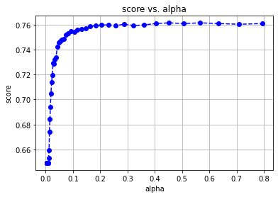

```
The optimaized alpha and score of Lasso linear is: 0.4519621238647762 ,0.7613762486126526
```

```python
from sklearn.model_selection import train_test_split
from sklearn.linear_model import LogisticRegression
from sklearn.metrics import mean_squared_error, r2_score
from math import sqrt

lr_train, lr_validate = train_test_split(model_train, test_size=0.15, random_state = 0)

lr_train_x = lr_train.drop(['accepted'], axis = 1)
lr_validate_x = lr_validate.drop(['accepted'], axis = 1)
lr_train_y = lr_train['accepted']
lr_validate_y = lr_validate['accepted']

alphas = np.logspace (-2.5, -0.1, num=50)
# alphas= [1, 5, 10]
scores = np.empty_like(alphas)
opt_a = float('-inf')
max_score = float('-inf')
for i, a in enumerate(alphas):
    lasso = LogisticRegression(penalty='l1', C=a, solver='liblinear')
    lasso.fit(lr_train_x, lr_train_y)
    scores[i] = lasso.score(lr_validate_x, lr_validate_y)
    if scores[i] > max_score:
        max_score = scores[i]
        opt_a = a
        lasso_save = lasso
plt.plot(alphas, scores, color='b', linestyle='dashed', marker='o',markerfacecolor='blue', markersize=6)
plt.xlabel('alpha')
plt.ylabel('score')
plt.grid(True)
plt.title('score vs. alpha')
plt.show()
print('The optimaized alpha and score of Lasso linear is: ' + str(opt_a) + " ," + str(max_score))
```

```python
# combine the validate data and training data, use the optimal alpha, re-train the model
best_LR_model = LogisticRegression(penalty='l1', C=opt_a, solver='liblinear')
best_LR_model.fit(model_train_x, model_train_y)
```

```
LogisticRegression(C=0.4519621238647762, class_weight=None, dual=False,
                   fit_intercept=True, intercept_scaling=1, l1_ratio=None,
                   max_iter=100, multi_class='auto', n_jobs=None, penalty='l1',
                   random_state=None, solver='liblinear', tol=0.0001, verbose=0,
                   warm_start=False)
```

### Model evaluation

#### Confusion matrix

```python
from sklearn.metrics import confusion_matrix
from sklearn.metrics import classification_report
from sklearn.metrics import precision_score
from sklearn.metrics import recall_score

# calculate accuracy, precision and recall, [[tn, fp],[]]
def cal_evaluation(classifier, cm):
    tn = cm[0][0]
    fp = cm[0][1]
    fn = cm[1][0]
    tp = cm[1][1]
    accuracy  = (tp + tn) / (tp + fp + fn + tn + 0.0)
    precision = tp / (tp + fp + 0.0)
    recall = tp / (tp + fn + 0.0)
    print (classifier)
    print ("Accuracy is: %0.3f" % accuracy)
    print ("precision is: %0.3f" % precision)
    print ("recall is: %0.3f" % recall)

# print out confusion matrices
def draw_confusion_matrices(confusion_matricies):
    class_names = ['Not_accepted','Accepted']
    for cm in confusion_matrices:
        classifier, cm = cm[0], cm[1]
        cal_evaluation(classifier, cm)
        fig = plt.figure()
        ax = fig.add_subplot(111)
        cax = ax.matshow(cm, interpolation='nearest',cmap=plt.get_cmap('Reds'))
        plt.title('Confusion matrix for %s' % classifier)
        fig.colorbar(cax)
        ax.set_xticklabels([''] + class_names)
        ax.set_yticklabels([''] + class_names)
        plt.xlabel('Predicted')
        plt.ylabel('True')
        plt.show()
```

```python
confusion_matrix(model_test_y, best_LR_model.predict(model_test_x))
```

```
array([[1263,   86],
       [ 434,  337]])
```

```
Logistic Regression
Accuracy is: 0.755
precision is: 0.797
recall is: 0.437
```

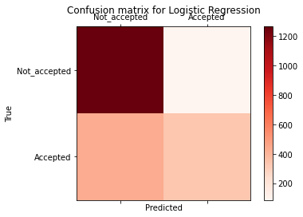

```python
%matplotlib inline

# Confusion matrix, accuracy, precison and recall for random forest and logistic regression
confusion_matrices = [
    ("Logistic Regression", confusion_matrix(model_test_y, best_LR_model.predict(model_test_x))),
]

draw_confusion_matrices(confusion_matrices)
```

#### ROC & AUC

```python
from sklearn.metrics import roc_curve
from sklearn import metrics

# Use predict_proba to get the probability results of Logistic Regression
y_pred_lr = best_LR_model.predict_proba(model_test_x)[:, 1]
fpr_lr, tpr_lr, _ = roc_curve(model_test_y, y_pred_lr)
```

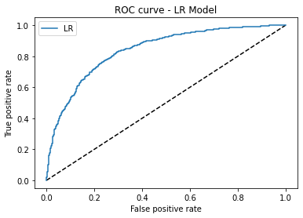

```python
# ROC Curve
plt.figure(1)
plt.plot([0, 1], [0, 1], 'k--')
plt.plot(fpr_lr, tpr_lr, label='LR')
plt.xlabel('False positive rate')
plt.ylabel('True positive rate')
plt.title('ROC curve - LR Model')
plt.legend(loc='best')
plt.show()
```

```python
# AUC score
metrics.auc(fpr_lr,tpr_lr)
```

```
0.8399246595691289
```

### Feature selection

```python
# Store the coef for feature selection
res = pd.DataFrame(columns=['Feature', 'Coef'])

for k,v in sorted(zip(map(lambda x: round(x, 4), best_LR_model.fit(model_train_x, model_train_y).coef_[0]), \
                      model_train_x.columns), key=lambda k_v:(-abs(k_v[0]),k_v[1])):
    print (v + ": " + str(k))
    res = res.append({'Feature': v, 'Coef': k}, ignore_index=True)
```

```
total_interactions: 31.2076
interaction*past_booker: 5.4712
total_reviews: 4.1901
lead_time: -3.9784
contact_me*lead_time: 2.736
reply_t: -2.5399
days_of_stay: -1.2737
interaction*message_length: 1.1333
contact_me: 0.2366
past_booker: -0.2283
guest_size: -0.1764
contact_me*guest size: 0.0
contact_me*past_booker: 0.0
interaction*days_of_stay: 0.0
interaction*lead_time: 0.0
message_length: 0.0
message_length*days_of_stay: 0.0
message_length*lead_time: 0.0
```

Interactions, reviews, lead_time, reply_t, days_of_stay are important features according to logistic regression models with numerical features.

## Logistic regression (binned numerical)

```python
# Check what features are included
replied_inquiries = replied_inquiries_df.copy()
replied_inquiries = replied_inquiries.drop(columns=['Unnamed: 0'])

replied_inquiries.info()
```

```
<class 'pandas.core.frame.DataFrame'>
RangeIndex: 14129 entries, 0 to 14128
Data columns (total 10 columns):
 #   Column              Non-Null Count  Dtype
---  ------              --------------  -----
 0   guest_size          14129 non-null  float64
 1   total_interactions  14129 non-null  int64
 2   message_length      14129 non-null  float64
 3   total_reviews       14129 non-null  float64
 4   lead_time           14129 non-null  int64
 5   days_of_stay        14129 non-null  int64
 6   reply_t             14129 non-null  float64
 7   accepted            14129 non-null  int64
 8   contact_me          14129 non-null  int64
 9   past_booker         14129 non-null  int64
dtypes: float64(4), int64(6)
memory usage: 1.1 MB
```

### Feature Preprocessing

#### Feature encoding

In order to see the nuances of some features' impact, I decided to create buckets for numerical variables including:

- Interaction
- Review
- Lead time
- Days of stay
- Message length
- Guest size

And these bins will be used to create interactive features as well

```python
# Binning interactions
interaction = [0,10,20,30,1000]
interaction_range = ['1-10','11-20','21-30','>30']
interactions_bin = pd.cut(replied_inquiries['total_interactions'], bins = interaction, labels= interaction_range)
replied_inquiries['interactions'] = interactions_bin

# Binning reviews
review = [-1,0,10,20,30,1000]
review_range = ['0','1-10','11-20','21-30','>30']
reviews_bin = pd.cut(replied_inquiries['total_reviews'], bins = review, labels=review_range)
replied_inquiries['reviews'] = reviews_bin

# Binning lead time
lead = [-1,30,60,90,1000]
lead_range = ['1-30d','31-60d','61-90d', '>90d']
lead_bin = pd.cut(replied_inquiries['lead_time'], bins = lead, labels=lead_range)
replied_inquiries['lead_time'] = lead_bin

# Binning days_of_stay
stay = [-1,5,10,15,1000]
stay_range = ['1-5d','6-10d','11-15d','>15d']
stay_bin = pd.cut(replied_inquiries['days_of_stay'], bins = stay, labels=stay_range)
replied_inquiries['days_of_stay'] = stay_bin

# Binning message_length
length = [-1,150,300,450,3000]
length_range = ['0-150','151-300','301-450','>450']
length_bin = pd.cut(replied_inquiries['message_length'], bins = length, labels=length_range)
replied_inquiries['message_length'] = length_bin

# Binning guest size
size = [-1,1,2,4,6,30]
size_range = ['1','2','3-4','5-6','>6']
size_bin = pd.cut(replied_inquiries['guest_size'], bins = size, labels=size_range)
replied_inquiries['guest_size'] = size_bin
```

```python
# generate binary values using get_dummies
replied_inquiries = pd.get_dummies(replied_inquiries, columns=["interactions", "reviews", "lead_time", "days_of_stay", "message_length", "guest_size"] )
```

```python
# Drop columns not to be used
replied_inquiries = replied_inquiries.drop(['total_interactions', 'total_reviews'], axis = 1)
```

```python
replied_inquiries.info()
```

```
<class 'pandas.core.frame.DataFrame'>
RangeIndex: 14129 entries, 0 to 14128
Data columns (total 30 columns):
 #   Column                  Non-Null Count  Dtype
---  ------                  --------------  -----
 0   reply_t                 14129 non-null  float64
 1   accepted                14129 non-null  int64
 2   contact_me              14129 non-null  int64
 3   past_booker             14129 non-null  int64
 4   interactions_1-10       14129 non-null  uint8
 5   interactions_11-20      14129 non-null  uint8
 6   interactions_21-30      14129 non-null  uint8
 7   interactions_>30        14129 non-null  uint8
 8   reviews_0               14129 non-null  uint8
 9   reviews_1-10            14129 non-null  uint8
```

[output cut: 22 more lines]

#### Interaction features

Creat interaction features to discover combined effects of independent variables

```python
# Interaction features

interactions = replied_inquiries.columns[4:8]
reviews = replied_inquiries.columns[8:13]
lead_times = replied_inquiries.columns[13:17]
stays = replied_inquiries.columns[17:21]
message_lengths = replied_inquiries.columns[21:25]
guest_sizes = replied_inquiries.columns[25:30]

# Interaction * message length
for i in interactions:
  for j in message_lengths:
    replied_inquiries[i+'*'+j] = replied_inquiries[i] * replied_inquiries[j]

# Interaction * lead time
for i in interactions:
  for j in lead_times:
    replied_inquiries[i+'*'+j] = replied_inquiries[i] * replied_inquiries[j]

# Interaction * days of stay
for i in interactions:
  for j in stays:
    replied_inquiries[i+'*'+j] = replied_inquiries[i] * replied_inquiries[j]

# User stage + interactions
for i in interactions:
    replied_inquiries['past_booker'+'*'+i] = replied_inquiries['past_booker'] * replied_inquiries[i]

# Channel * user stage
replied_inquiries['contact_me*past_booker'] = replied_inquiries['contact_me'] * replied_inquiries['past_booker']

# Channel * lead_time
for i in lead_times:
  replied_inquiries['contact_me'+'*'+i] = replied_inquiries['contact_me'] * replied_inquiries[i]

# Channel * guest size
for i in guest_sizes:
  replied_inquiries['contact_me'+'*'+i] = replied_inquiries['contact_me'] * replied_inquiries[i]

# Message length * days of stay
for i in message_lengths:
  for j in stays:
    replied_inquiries[i+'*'+j] = replied_inquiries[i] * replied_inquiries[j]

# Message length * lead time
for i in message_lengths:
  for j in lead_times:
    replied_inquiries[i+'*'+j] = replied_inquiries[i] * replied_inquiries[j]
```

```python
replied_inquiries.head(10)
```

|  | reply_t | accepted | contact_me | past_booker | interactions_1-10 | interactions_11-20 | interactions_21-30 | interactions_>30 | reviews_0 | reviews_1-10 | reviews_11-20 | reviews_21-30 | reviews_>30 | lead_time_1-30d | lead_time_31-60d | lead_time_61-90d | lead_time_>90d | days_of_stay_1-5d | days_of_stay_6-10d | days_of_stay_11-15d | days_of_stay_>15d | message_length_0-150 | message_length_151-300 | message_length_301-450 | message_length_>450 | guest_size_1 | guest_size_2 | guest_size_3-4 | guest_size_5-6 | … |
| --- | --- | --- | --- | --- | --- | --- | --- | --- | --- | --- | --- | --- | --- | --- | --- | --- | --- | --- | --- | --- | --- | --- | --- | --- | --- | --- | --- | --- | --- | --- |
| 0 | 83.583 | 0 | 1 | 1 | 1 | 0 | 0 | 0 | 1 | 0 | 0 | 0 | 0 | 0 | 0 | 0 | 1 | 0 | 0 | 1 | 0 | 0 | 0 | 1 | 0 | 0 | 0 | 0 | 1 | … |
| 1 | 159.150 | 0 | 1 | 0 | 1 | 0 | 0 | 0 | 0 | 0 | 0 | 0 | 1 | 0 | 1 | 0 | 0 | 0 | 1 | 0 | 0 | 0 | 1 | 0 | 0 | 1 | 0 | 0 | 0 | … |
| 2 | 264.033 | 0 | 1 | 0 | 1 | 0 | 0 | 0 | 1 | 0 | 0 | 0 | 0 | 1 | 0 | 0 | 0 | 1 | 0 | 0 | 0 | 0 | 0 | 1 | 0 | 1 | 0 | 0 | 0 | … |
| 3 | 2.567 | 1 | 1 | 1 | 1 | 0 | 0 | 0 | 1 | 0 | 0 | 0 | 0 | 0 | 0 | 1 | 0 | 0 | 1 | 0 | 0 | 1 | 0 | 0 | 0 | 0 | 0 | 0 | 1 | … |
| 4 | 4.867 | 0 | 0 | 0 | 1 | 0 | 0 | 0 | 0 | 1 | 0 | 0 | 0 | 0 | 0 | 0 | 1 | 1 | 0 | 0 | 0 | 1 | 0 | 0 | 0 | 0 | 0 | 1 | 0 | … |
| 5 | 1269.617 | 0 | 1 | 0 | 1 | 0 | 0 | 0 | 0 | 1 | 0 | 0 | 0 | 1 | 0 | 0 | 0 | 1 | 0 | 0 | 0 | 1 | 0 | 0 | 0 | 0 | 0 | 1 | 0 | … |
| 6 | 4246.633 | 0 | 0 | 0 | 1 | 0 | 0 | 0 | 1 | 0 | 0 | 0 | 0 | 0 | 0 | 1 | 0 | 1 | 0 | 0 | 0 | 0 | 1 | 0 | 0 | 0 | 0 | 1 | 0 | … |
| 7 | 2370.017 | 0 | 0 | 0 | 1 | 0 | 0 | 0 | 0 | 0 | 1 | 0 | 0 | 0 | 0 | 0 | 1 | 0 | 0 | 1 | 0 | 0 | 1 | 0 | 0 | 0 | 0 | 1 | 0 | … |
| 8 | 22.050 | 1 | 0 | 1 | 0 | 0 | 0 | 1 | 0 | 1 | 0 | 0 | 0 | 0 | 1 | 0 | 0 | 0 | 0 | 0 | 1 | 0 | 0 | 1 | 0 | 1 | 0 | 0 | 0 | … |
| 9 | 16.333 | 0 | 0 | 1 | 1 | 0 | 0 | 0 | 0 | 0 | 0 | 1 | 0 | 0 | 1 | 0 | 0 | 0 | 1 | 0 | 0 | 1 | 0 | 0 | 0 | 0 | 0 | 1 | 0 | … |

10 rows × 124 columns

#### Feature scaling

```python
# Scale reply_t (MinMax scaling)
sc_scale = preprocessing.MinMaxScaler().fit(replied_inquiries[['reply_t']])
replied_inquiries[['reply_t']] = sc_scale.transform(replied_inquiries[['reply_t']])
```

```python
replied_inquiries.head(10)
```

|  | reply_t | accepted | contact_me | past_booker | interactions_1-10 | interactions_11-20 | interactions_21-30 | interactions_>30 | reviews_0 | reviews_1-10 | reviews_11-20 | reviews_21-30 | reviews_>30 | lead_time_1-30d | lead_time_31-60d | lead_time_61-90d | lead_time_>90d | days_of_stay_1-5d | days_of_stay_6-10d | days_of_stay_11-15d | days_of_stay_>15d | message_length_0-150 | message_length_151-300 | message_length_301-450 | message_length_>450 | guest_size_1 | guest_size_2 | guest_size_3-4 | guest_size_5-6 | … |
| --- | --- | --- | --- | --- | --- | --- | --- | --- | --- | --- | --- | --- | --- | --- | --- | --- | --- | --- | --- | --- | --- | --- | --- | --- | --- | --- | --- | --- | --- | --- |
| 0 | 0.000 | 0 | 1 | 1 | 1 | 0 | 0 | 0 | 1 | 0 | 0 | 0 | 0 | 0 | 0 | 0 | 1 | 0 | 0 | 1 | 0 | 0 | 0 | 1 | 0 | 0 | 0 | 0 | 1 | … |
| 1 | 0.000 | 0 | 1 | 0 | 1 | 0 | 0 | 0 | 0 | 0 | 0 | 0 | 1 | 0 | 1 | 0 | 0 | 0 | 1 | 0 | 0 | 0 | 1 | 0 | 0 | 1 | 0 | 0 | 0 | … |
| 2 | 0.000 | 0 | 1 | 0 | 1 | 0 | 0 | 0 | 1 | 0 | 0 | 0 | 0 | 1 | 0 | 0 | 0 | 1 | 0 | 0 | 0 | 0 | 0 | 1 | 0 | 1 | 0 | 0 | 0 | … |
| 3 | 0.000 | 1 | 1 | 1 | 1 | 0 | 0 | 0 | 1 | 0 | 0 | 0 | 0 | 0 | 0 | 1 | 0 | 0 | 1 | 0 | 0 | 1 | 0 | 0 | 0 | 0 | 0 | 0 | 1 | … |
| 4 | 0.000 | 0 | 0 | 0 | 1 | 0 | 0 | 0 | 0 | 1 | 0 | 0 | 0 | 0 | 0 | 0 | 1 | 1 | 0 | 0 | 0 | 1 | 0 | 0 | 0 | 0 | 0 | 1 | 0 | … |
| 5 | 0.002 | 0 | 1 | 0 | 1 | 0 | 0 | 0 | 0 | 1 | 0 | 0 | 0 | 1 | 0 | 0 | 0 | 1 | 0 | 0 | 0 | 1 | 0 | 0 | 0 | 0 | 0 | 1 | 0 | … |
| 6 | 0.007 | 0 | 0 | 0 | 1 | 0 | 0 | 0 | 1 | 0 | 0 | 0 | 0 | 0 | 0 | 1 | 0 | 1 | 0 | 0 | 0 | 0 | 1 | 0 | 0 | 0 | 0 | 1 | 0 | … |
| 7 | 0.004 | 0 | 0 | 0 | 1 | 0 | 0 | 0 | 0 | 0 | 1 | 0 | 0 | 0 | 0 | 0 | 1 | 0 | 0 | 1 | 0 | 0 | 1 | 0 | 0 | 0 | 0 | 1 | 0 | … |
| 8 | 0.000 | 1 | 0 | 1 | 0 | 0 | 0 | 1 | 0 | 1 | 0 | 0 | 0 | 0 | 1 | 0 | 0 | 0 | 0 | 0 | 1 | 0 | 0 | 1 | 0 | 1 | 0 | 0 | 0 | … |
| 9 | 0.000 | 0 | 0 | 1 | 1 | 0 | 0 | 0 | 0 | 0 | 0 | 1 | 0 | 0 | 1 | 0 | 0 | 0 | 1 | 0 | 0 | 1 | 0 | 0 | 0 | 0 | 0 | 1 | 0 | … |

10 rows × 124 columns

#### Split training and test data

```python
from sklearn.model_selection import train_test_split

model_train, model_test = train_test_split(replied_inquiries, test_size=0.15, random_state = 3)
model_train_x = model_train.drop(['accepted'], axis = 1)
model_test_x = model_test.drop(['accepted'], axis = 1)
model_train_y = model_train['accepted']
model_test_y = model_test['accepted']
```

### Train model and find optimal hypermarameters

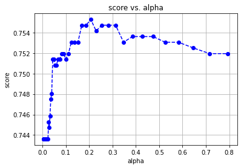

```
The optimaized alpha and score of Lasso linear is: 0.20716983998953076 ,0.7552719200887902
```

```python
from sklearn.model_selection import train_test_split
from sklearn.linear_model import LogisticRegression
from sklearn.metrics import mean_squared_error, r2_score
from math import sqrt

lr_train, lr_validate = train_test_split(model_train, test_size=0.15, random_state = 0)

lr_train_x = lr_train.drop(['accepted'], axis = 1)
lr_validate_x = lr_validate.drop(['accepted'], axis = 1)
lr_train_y = lr_train['accepted']
lr_validate_y = lr_validate['accepted']

alphas = np.logspace (-2.3, -0.1, num=50)
# alphas= [1, 5, 10]
scores = np.empty_like(alphas)
opt_a = float('-inf')
max_score = float('-inf')
for i, a in enumerate(alphas):
    lasso = LogisticRegression(penalty='l1', C=a, solver='liblinear')
    lasso.fit(lr_train_x, lr_train_y)
    scores[i] = lasso.score(lr_validate_x, lr_validate_y)
    if scores[i] > max_score:
        max_score = scores[i]
        opt_a = a
        lasso_save = lasso
plt.plot(alphas, scores, color='b', linestyle='dashed', marker='o',markerfacecolor='blue', markersize=6)
plt.xlabel('alpha')
plt.ylabel('score')
plt.grid(True)
plt.title('score vs. alpha')
plt.show()
print('The optimaized alpha and score of Lasso linear is: ' + str(opt_a) + " ," + str(max_score))
```

```python
# combine the validate data and training data, use the optimal alpha, re-train the model
best_LR_model = LogisticRegression(penalty='l1', C=opt_a, solver='liblinear')
best_LR_model.fit(model_train_x, model_train_y)
```

```
LogisticRegression(C=0.20716983998953076, class_weight=None, dual=False,
                   fit_intercept=True, intercept_scaling=1, l1_ratio=None,
                   max_iter=100, multi_class='auto', n_jobs=None, penalty='l1',
                   random_state=None, solver='liblinear', tol=0.0001, verbose=0,
                   warm_start=False)
```

### Model evaluation

#### Confusion matrix

```python
from sklearn.metrics import confusion_matrix
from sklearn.metrics import classification_report
from sklearn.metrics import precision_score
from sklearn.metrics import recall_score

# calculate accuracy, precision and recall, [[tn, fp],[]]
def cal_evaluation(classifier, cm):
    tn = cm[0][0]
    fp = cm[0][1]
    fn = cm[1][0]
    tp = cm[1][1]
    accuracy  = (tp + tn) / (tp + fp + fn + tn + 0.0)
    precision = tp / (tp + fp + 0.0)
    recall = tp / (tp + fn + 0.0)
    print (classifier)
    print ("Accuracy is: %0.3f" % accuracy)
    print ("precision is: %0.3f" % precision)
    print ("recall is: %0.3f" % recall)

# print out confusion matrices
def draw_confusion_matrices(confusion_matricies):
    class_names = ['Not_accepted','Accepted']
    for cm in confusion_matrices:
        classifier, cm = cm[0], cm[1]
        cal_evaluation(classifier, cm)
        fig = plt.figure()
        ax = fig.add_subplot(111)
        cax = ax.matshow(cm, interpolation='nearest',cmap=plt.get_cmap('Reds'))
        plt.title('Confusion matrix for %s' % classifier)
        fig.colorbar(cax)
        ax.set_xticklabels([''] + class_names)
        ax.set_yticklabels([''] + class_names)
        plt.xlabel('Predicted')
        plt.ylabel('True')
        plt.show()
```

```python
confusion_matrix(model_test_y, best_LR_model.predict(model_test_x))
```

```
array([[1256,   93],
       [ 440,  331]])
```

```
Logistic Regression
Accuracy is: 0.749
precision is: 0.781
recall is: 0.429
```

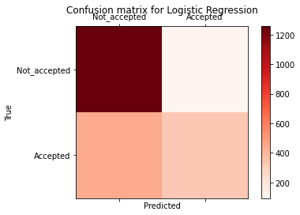

```python
%matplotlib inline

# Confusion matrix, accuracy, precison and recall for random forest and logistic regression
confusion_matrices = [
    ("Logistic Regression", confusion_matrix(model_test_y, best_LR_model.predict(model_test_x))),
    #("Logistic Regression", confusion_matrix(yc_test,best_LR_model.predict(Xc_test))),
]

draw_confusion_matrices(confusion_matrices)
```

#### ROC & AUC

```python
from sklearn.metrics import roc_curve
from sklearn import metrics

# Use predict_proba to get the probability results of Logistic Regression
y_pred_lr = best_LR_model.predict_proba(model_test_x)[:, 1]
fpr_lr, tpr_lr, _ = roc_curve(model_test_y, y_pred_lr)
```

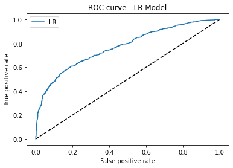

```python
# ROC Curve
plt.figure(1)
plt.plot([0, 1], [0, 1], 'k--')
plt.plot(fpr_lr, tpr_lr, label='LR')
plt.xlabel('False positive rate')
plt.ylabel('True positive rate')
plt.title('ROC curve - LR Model')
plt.legend(loc='best')
plt.show()
```

```python
# AUC score
metrics.auc(fpr_lr,tpr_lr)
```

```
0.7704121513846545
```

### Feature selection

```python
# Store the coef for feature selection
res = pd.DataFrame(columns=['Feature', 'Coef'])

for k,v in sorted(zip(map(lambda x: round(x, 4), best_LR_model.fit(model_train_x, model_train_y).coef_[0]), \
                      model_train_x.columns), key=lambda k_v:(-abs(k_v[0]),k_v[1])):
    print (v + ": " + str(k))
    res = res.append({'Feature': v, 'Coef': k}, ignore_index=True)
```

```
interactions_1-10: -1.7172
interactions_1-10*lead_time_>90d: -0.8044
interactions_>30: 0.7933
reviews_>30: 0.7891
interactions_21-30: 0.7773
reviews_21-30: 0.7653
reviews_11-20: 0.5894
reviews_0: -0.5848
contact_me*lead_time_>90d: 0.4788
contact_me: 0.4643
interactions_11-20*lead_time_>90d: -0.427
interactions_11-20*days_of_stay_>15d: -0.3412
interactions_1-10*days_of_stay_1-5d: -0.3261
contact_me*lead_time_1-30d: -0.3205
interactions_21-30*message_length_0-150: -0.2922
contact_me*lead_time_61-90d: 0.286
message_length_151-300*days_of_stay_1-5d: 0.281
lead_time_31-60d: 0.2788
past_booker*interactions_1-10: -0.2728
days_of_stay_11-15d: 0.2134
interactions_11-20*days_of_stay_1-5d: 0.1999
past_booker: 0.1889
contact_me*guest_size_1: -0.1525
past_booker*interactions_>30: 0.1488
message_length_301-450: 0.1454
past_booker*interactions_11-20: 0.136
interactions_1-10*days_of_stay_6-10d: -0.1242
lead_time_1-30d: 0.1157
guest_size_5-6: -0.11
message_length_151-300*days_of_stay_6-10d: 0.0951
guest_size_1: 0.0914
message_length_301-450*lead_time_1-30d: 0.0836
days_of_stay_>15d: -0.0759
lead_time_>90d: -0.0742
interactions_1-10*message_length_151-300: -0.0709
message_length_0-150*days_of_stay_1-5d: 0.0695
message_length_151-300*days_of_stay_11-15d: -0.0541
message_length_0-150*lead_time_>90d: 0.0508
message_length_0-150*lead_time_61-90d: -0.0376
message_length_0-150*days_of_stay_6-10d: -0.0337
```

[output cut: 68 more lines]

```
message_length_301-450*days_of_stay_>15d: 0.0
message_length_301-450*lead_time_31-60d: 0.0
message_length_301-450*lead_time_61-90d: 0.0
message_length_301-450*lead_time_>90d: 0.0
message_length_>450: 0.0
message_length_>450*days_of_stay_1-5d: 0.0
message_length_>450*days_of_stay_11-15d: 0.0
message_length_>450*days_of_stay_6-10d: 0.0
message_length_>450*days_of_stay_>15d: 0.0
message_length_>450*lead_time_1-30d: 0.0
message_length_>450*lead_time_31-60d: 0.0
message_length_>450*lead_time_61-90d: 0.0
past_booker*interactions_21-30: 0.0
reply_t: 0.0
reviews_1-10: 0.0
```

interactions, reviews, lead_time, channel(contact_me), days_of_stay are the most important features according to logistic regression model for binned numerical features

## Final model (logistic regression with binned important features )

- RF model results: **interactions**, **reply_t**, **lead_time**, message_length, and reviews are the most important features
- Logistic regression model with numerical features: **interactions**, **reviews**, **lead_time**, **reply_t**, **days_of_stay** are important features
- Logistic regression model fore binned numerical features: **interactions**, **reviews**, **lead_time**, channel(contact_me), **days_of_stay** are the most important features

RF model has the best performance(AUC score: 0.86), but in order to see the interactions between features more clearly, I would still use logistic regression model with binned numerical features(AUC score: 0.77) as the final model

```python
# Check what features are included
replied_inquiries = replied_inquiries_df.copy()
replied_inquiries = replied_inquiries[['total_interactions', 'total_reviews', 'lead_time', 'days_of_stay', 'reply_t', 'contact_me', 'accepted']]

replied_inquiries.info()
```

```
<class 'pandas.core.frame.DataFrame'>
RangeIndex: 14129 entries, 0 to 14128
Data columns (total 7 columns):
 #   Column              Non-Null Count  Dtype
---  ------              --------------  -----
 0   total_interactions  14129 non-null  int64
 1   total_reviews       14129 non-null  float64
 2   lead_time           14129 non-null  int64
 3   days_of_stay        14129 non-null  int64
 4   reply_t             14129 non-null  float64
 5   contact_me          14129 non-null  int64
 6   accepted            14129 non-null  int64
dtypes: float64(2), int64(5)
memory usage: 772.8 KB
```

### Feature Preprocessing

#### Feature encoding

```python
# Binning interactions
interaction = [0,10,20,30,1000]
interaction_range = ['1-10','11-20','21-30','>30']
interactions_bin = pd.cut(replied_inquiries['total_interactions'], bins = interaction, labels= interaction_range)
replied_inquiries['interactions'] = interactions_bin

# Binning reviews
review = [-1,0,10,20,30,1000]
review_range = ['0','1-10','11-20','21-30','>30']
reviews_bin = pd.cut(replied_inquiries['total_reviews'], bins = review, labels=review_range)
replied_inquiries['reviews'] = reviews_bin

# Binning lead time
lead = [-1,30,60,90,1000]
lead_range = ['1-30d','31-60d','61-90d', '>90d']
lead_bin = pd.cut(replied_inquiries['lead_time'], bins = lead, labels=lead_range)
replied_inquiries['lead_time'] = lead_bin

# Binning days_of_stay
stay = [-1,5,10,15,1000]
stay_range = ['1-5d','6-10d','11-15d','>15d']
stay_bin = pd.cut(replied_inquiries['days_of_stay'], bins = stay, labels=stay_range)
replied_inquiries['days_of_stay'] = stay_bin
```

```python
# generate binary values using get_dummies
replied_inquiries = pd.get_dummies(replied_inquiries, columns=["interactions", "reviews", "lead_time", "days_of_stay"] )
```

```python
# Drop columns not to be used
replied_inquiries = replied_inquiries.drop(['total_interactions', 'total_reviews'], axis = 1)
```

```python
replied_inquiries.info()
```

```
<class 'pandas.core.frame.DataFrame'>
RangeIndex: 14129 entries, 0 to 14128
Data columns (total 20 columns):
 #   Column               Non-Null Count  Dtype
---  ------               --------------  -----
 0   reply_t              14129 non-null  float64
 1   contact_me           14129 non-null  int64
 2   accepted             14129 non-null  int64
 3   interactions_1-10    14129 non-null  uint8
 4   interactions_11-20   14129 non-null  uint8
 5   interactions_21-30   14129 non-null  uint8
 6   interactions_>30     14129 non-null  uint8
 7   reviews_0            14129 non-null  uint8
 8   reviews_1-10         14129 non-null  uint8
 9   reviews_11-20        14129 non-null  uint8
 10  reviews_21-30        14129 non-null  uint8
 11  reviews_>30          14129 non-null  uint8
 12  lead_time_1-30d      14129 non-null  uint8
 13  lead_time_31-60d     14129 non-null  uint8
 14  lead_time_61-90d     14129 non-null  uint8
 15  lead_time_>90d       14129 non-null  uint8
 16  days_of_stay_1-5d    14129 non-null  uint8
 17  days_of_stay_6-10d   14129 non-null  uint8
 18  days_of_stay_11-15d  14129 non-null  uint8
 19  days_of_stay_>15d    14129 non-null  uint8
dtypes: float64(1), int64(2), uint8(17)
memory usage: 565.8 KB
```

#### Interaction features

Creat interaction features to discover combined effects of independent variables

```python
# Interaction features

interactions = replied_inquiries.columns[3:7]
reviews = replied_inquiries.columns[7:12]
lead_times = replied_inquiries.columns[12:16]
stays = replied_inquiries.columns[16:20]

# Interaction * lead time
for i in interactions:
  for j in lead_times:
    replied_inquiries[i+'*'+j] = replied_inquiries[i] * replied_inquiries[j]

# Interaction * days of stay
for i in interactions:
  for j in stays:
    replied_inquiries[i+'*'+j] = replied_inquiries[i] * replied_inquiries[j]

# Channel * lead_time
for i in lead_times:
  replied_inquiries['contact_me'+'*'+i] = replied_inquiries['contact_me'] * replied_inquiries[i]
```

```python
replied_inquiries.info()
```

```
<class 'pandas.core.frame.DataFrame'>
RangeIndex: 14129 entries, 0 to 14128
Data columns (total 56 columns):
 #   Column                                  Non-Null Count  Dtype
---  ------                                  --------------  -----
 0   reply_t                                 14129 non-null  float64
 1   contact_me                              14129 non-null  int64
 2   accepted                                14129 non-null  int64
 3   interactions_1-10                       14129 non-null  uint8
 4   interactions_11-20                      14129 non-null  uint8
 5   interactions_21-30                      14129 non-null  uint8
 6   interactions_>30                        14129 non-null  uint8
 7   reviews_0                               14129 non-null  uint8
 8   reviews_1-10                            14129 non-null  uint8
 9   reviews_11-20                           14129 non-null  uint8
```

[output cut: 48 more lines]

#### Feature scaling

```python
# Scale reply_t (MinMax scaling)
sc_scale = preprocessing.MinMaxScaler().fit(replied_inquiries[['reply_t']])
replied_inquiries[['reply_t']] = sc_scale.transform(replied_inquiries[['reply_t']])
```

#### Split training and test data

```python
from sklearn.model_selection import train_test_split

model_train, model_test = train_test_split(replied_inquiries, test_size=0.15, random_state = 3)
model_train_x = model_train.drop(['accepted'], axis = 1)
model_test_x = model_test.drop(['accepted'], axis = 1)
model_train_y = model_train['accepted']
model_test_y = model_test['accepted']
```

### Train model and find optimal hypermarameters

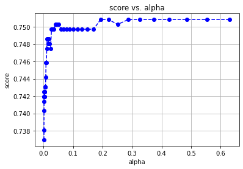

[output not shown]

```python
from sklearn.model_selection import train_test_split
from sklearn.linear_model import LogisticRegression
from sklearn.metrics import mean_squared_error, r2_score
from math import sqrt

lr_train, lr_validate = train_test_split(model_train, test_size=0.15, random_state = 0)

lr_train_x = lr_train.drop(['accepted'], axis = 1)
lr_validate_x = lr_validate.drop(['accepted'], axis = 1)
lr_train_y = lr_train['accepted']
lr_validate_y = lr_validate['accepted']

alphas = np.logspace (-3, -0.2, num=50)
# alphas= [1, 5, 10]
scores = np.empty_like(alphas)
opt_a = float('-inf')
max_score = float('-inf')
for i, a in enumerate(alphas):
    lasso = LogisticRegression(penalty='l2', C=a, solver='liblinear')
    lasso.fit(lr_train_x, lr_train_y)
    scores[i] = lasso.score(lr_validate_x, lr_validate_y)
    if scores[i] > max_score:
        max_score = scores[i]
        opt_a = a
        lasso_save = lasso
plt.plot(alphas, scores, color='b', linestyle='dashed', marker='o',markerfacecolor='blue', markersize=6)
plt.xlabel('alpha')
plt.ylabel('score')
plt.grid(True)
plt.title('score vs. alpha')
plt.show()
print('The optimaized alpha and score of Ridge linear is: ' + str(opt_a) + " ," + str(max_score))
```

```python
# combine the validate data and training data, use the optimal alpha, re-train the model
best_LR_model = LogisticRegression(penalty='l2', C=opt_a, solver='liblinear')
best_LR_model.fit(model_train_x, model_train_y)
```

```
LogisticRegression(C=0.19306977288832497, class_weight=None, dual=False,
                   fit_intercept=True, intercept_scaling=1, l1_ratio=None,
                   max_iter=100, multi_class='auto', n_jobs=None, penalty='l2',
                   random_state=None, solver='liblinear', tol=0.0001, verbose=0,
                   warm_start=False)
```

### Model evaluation

#### Confusion matrix

```python
from sklearn.metrics import confusion_matrix
from sklearn.metrics import classification_report
from sklearn.metrics import precision_score
from sklearn.metrics import recall_score

# calculate accuracy, precision and recall, [[tn, fp],[]]
def cal_evaluation(classifier, cm):
    tn = cm[0][0]
    fp = cm[0][1]
    fn = cm[1][0]
    tp = cm[1][1]
    accuracy  = (tp + tn) / (tp + fp + fn + tn + 0.0)
    precision = tp / (tp + fp + 0.0)
    recall = tp / (tp + fn + 0.0)
    print (classifier)
    print ("Accuracy is: %0.3f" % accuracy)
    print ("precision is: %0.3f" % precision)
    print ("recall is: %0.3f" % recall)

# print out confusion matrices
def draw_confusion_matrices(confusion_matricies):
    class_names = ['Not_accepted','Accepted']
    for cm in confusion_matrices:
        classifier, cm = cm[0], cm[1]
        cal_evaluation(classifier, cm)
        fig = plt.figure()
        ax = fig.add_subplot(111)
        cax = ax.matshow(cm, interpolation='nearest',cmap=plt.get_cmap('Reds'))
        plt.title('Confusion matrix for %s' % classifier)
        fig.colorbar(cax)
        ax.set_xticklabels([''] + class_names)
        ax.set_yticklabels([''] + class_names)
        plt.xlabel('Predicted')
        plt.ylabel('True')
        plt.show()
```

```python
confusion_matrix(model_test_y, best_LR_model.predict(model_test_x))
```

```
array([[1258,   91],
       [ 444,  327]])
```

```
Logistic Regression
Accuracy is: 0.748
precision is: 0.782
recall is: 0.424
```

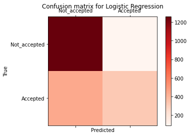

```python
%matplotlib inline

# Confusion matrix, accuracy, precison and recall for random forest and logistic regression
confusion_matrices = [
    ("Logistic Regression", confusion_matrix(model_test_y, best_LR_model.predict(model_test_x))),
    #("Logistic Regression", confusion_matrix(yc_test,best_LR_model.predict(Xc_test))),
]

draw_confusion_matrices(confusion_matrices)
```

#### ROC & AUC

```python
from sklearn.metrics import roc_curve
from sklearn import metrics

# Use predict_proba to get the probability results of Logistic Regression
y_pred_lr = best_LR_model.predict_proba(model_test_x)[:, 1]
fpr_lr, tpr_lr, _ = roc_curve(model_test_y, y_pred_lr)
```

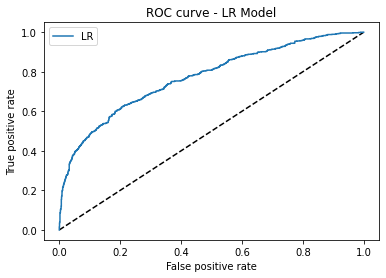

```python
# ROC Curve
plt.figure(1)
plt.plot([0, 1], [0, 1], 'k--')
plt.plot(fpr_lr, tpr_lr, label='LR')
plt.xlabel('False positive rate')
plt.ylabel('True positive rate')
plt.title('ROC curve - LR Model')
plt.legend(loc='best')
plt.show()
```

```python
# AUC score
metrics.auc(fpr_lr,tpr_lr)
```

```
0.771268817080241
```

### Results interpretation

```python
# Store the coef for results interpretation
res = pd.DataFrame(columns=['Feature', 'Coef'])

for k,v in sorted(zip(map(lambda x: round(x, 4), best_LR_model.fit(model_train_x, model_train_y).coef_[0]), \
                      model_train_x.columns), key=lambda k_v:(-abs(k_v[0]),k_v[1])):
    print (v + ": " + str(k))
    res = res.append({'Feature': v, 'Coef': k}, ignore_index=True)
```

```
interactions_1-10: -1.2019
interactions_>30: 0.8154
reviews_0: -0.8114
interactions_1-10*lead_time_>90d: -0.7353
interactions_21-30: 0.7191
reviews_>30: 0.5772
reply_t: -0.5754
reviews_21-30: 0.5628
interactions_>30*days_of_stay_>15d: 0.5489
interactions_1-10*days_of_stay_1-5d: -0.5128
contact_me*lead_time_>90d: 0.5018
interactions_21-30*days_of_stay_11-15d: 0.4891
contact_me: 0.465
reviews_11-20: 0.3802
contact_me*lead_time_1-30d: -0.3761
lead_time_31-60d: 0.3757
interactions_1-10*days_of_stay_6-10d: -0.3745
interactions_21-30*lead_time_>90d: 0.3742
contact_me*lead_time_61-90d: 0.3573
interactions_11-20*days_of_stay_1-5d: 0.3498
interactions_>30*lead_time_>90d: 0.331
interactions_11-20*days_of_stay_>15d: -0.2801
days_of_stay_11-15d: 0.266
interactions_21-30*days_of_stay_6-10d: 0.2525
lead_time_1-30d: 0.2261
reviews_1-10: -0.2255
interactions_>30*lead_time_31-60d: 0.2217
interactions_1-10*lead_time_61-90d: -0.2084
lead_time_>90d: -0.1999
interactions_21-30*days_of_stay_>15d: -0.199
interactions_>30*lead_time_1-30d: 0.1965
interactions_21-30*lead_time_61-90d: 0.187
interactions_21-30*days_of_stay_1-5d: 0.1765
interactions_1-10*days_of_stay_11-15d: -0.1762
interactions_11-20*lead_time_31-60d: 0.1703
interactions_11-20*lead_time_>90d: -0.1699
days_of_stay_1-5d: 0.1631
interactions_11-20: 0.1506
interactions_>30*days_of_stay_1-5d: 0.1496
interactions_>30*days_of_stay_6-10d: 0.1455
interactions_1-10*lead_time_31-60d: -0.1428
interactions_1-10*days_of_stay_>15d: -0.1384
interactions_21-30*lead_time_31-60d: 0.1266
days_of_stay_6-10d: 0.1228
interactions_1-10*lead_time_1-30d: -0.1154
interactions_11-20*lead_time_1-30d: 0.1137
interactions_11-20*days_of_stay_6-10d: 0.0993
lead_time_61-90d: 0.0812
days_of_stay_>15d: -0.0686
interactions_>30*lead_time_61-90d: 0.0662
interactions_11-20*lead_time_61-90d: 0.0365
interactions_21-30*lead_time_1-30d: 0.0313
interactions_>30*days_of_stay_11-15d: -0.0285
interactions_11-20*days_of_stay_11-15d: -0.0184
contact_me*lead_time_31-60d: -0.0179
```

```python
res = res.set_index('Feature')
```

```python
print('contact_me: ' + str(res.Coef.loc['contact_me']))
print('reply_t: ' + str(res.Coef.loc['reply_t']))
```

```
contact_me: 0.465
reply_t: -0.5754
```

Inquiries that are replied in contact me channel are more likely to be accepted

Inquiries with shorter reply times are more likely to be accepted

```python
for i in list(interactions):
  print(i + ": " + str(res.Coef.loc[i]))

for i in list(reviews):
  print(i + ": " + str(res.Coef.loc[i]))

for i in list(lead_times):
  print(i + ": " + str(res.Coef.loc[i]))

for i in list(stays):
  print(i + ": " + str(res.Coef.loc[i]))
```

```
interactions_1-10: -1.2019
interactions_11-20: 0.1506
interactions_21-30: 0.7191
interactions_>30: 0.8154
reviews_0: -0.8114
reviews_1-10: -0.2255
reviews_11-20: 0.3802
reviews_21-30: 0.5628
reviews_>30: 0.5772
lead_time_1-30d: 0.2261
lead_time_31-60d: 0.3757
lead_time_61-90d: 0.0812
lead_time_>90d: -0.1999
days_of_stay_1-5d: 0.1631
days_of_stay_6-10d: 0.1228
days_of_stay_11-15d: 0.266
days_of_stay_>15d: -0.0686
```

- More than 20 interactions significantly increases the probability of acceptance, and having less than 10 interactions decreases it
- Hosts whose listings have more than 10 reviews are more likely to accept the inquiries than those whose listings have less than 10 reviews
- Inquiries made 31-60 days before check-in most likely to be accepted, and inquiries made more than 90 days before check-in are likely to be rejected
- Inquiries for 11-15 days are most likely to be accepted, but inquiries for more than 15 days are more likely to be rejected

```python
for i in list(interactions):
  for j in list(lead_times):
    print(i + "*" + j + ": " + str(res.Coef.loc[i + "*" + j ]))
```

```
interactions_1-10*lead_time_1-30d: -0.1154
interactions_1-10*lead_time_31-60d: -0.1428
interactions_1-10*lead_time_61-90d: -0.2084
interactions_1-10*lead_time_>90d: -0.7353
interactions_11-20*lead_time_1-30d: 0.1137
interactions_11-20*lead_time_31-60d: 0.1703
interactions_11-20*lead_time_61-90d: 0.0365
interactions_11-20*lead_time_>90d: -0.1699
interactions_21-30*lead_time_1-30d: 0.0313
interactions_21-30*lead_time_31-60d: 0.1266
interactions_21-30*lead_time_61-90d: 0.187
interactions_21-30*lead_time_>90d: 0.3742
interactions_>30*lead_time_1-30d: 0.1965
interactions_>30*lead_time_31-60d: 0.2217
interactions_>30*lead_time_61-90d: 0.0662
interactions_>30*lead_time_>90d: 0.331
```

Having less than 10 interactions decreases the probability of acceptance across all lead times

Having more than 20 interactions increases the probability of acceptance across all lead times

```python
for i in list(interactions):
  for j in list(stays):
    print(i + "*" + j + ": " + str(res.Coef.loc[i + "*" + j ]))
```

```
interactions_1-10*days_of_stay_1-5d: -0.5128
interactions_1-10*days_of_stay_6-10d: -0.3745
interactions_1-10*days_of_stay_11-15d: -0.1762
interactions_1-10*days_of_stay_>15d: -0.1384
interactions_11-20*days_of_stay_1-5d: 0.3498
interactions_11-20*days_of_stay_6-10d: 0.0993
interactions_11-20*days_of_stay_11-15d: -0.0184
interactions_11-20*days_of_stay_>15d: -0.2801
interactions_21-30*days_of_stay_1-5d: 0.1765
interactions_21-30*days_of_stay_6-10d: 0.2525
interactions_21-30*days_of_stay_11-15d: 0.4891
interactions_21-30*days_of_stay_>15d: -0.199
interactions_>30*days_of_stay_1-5d: 0.1496
interactions_>30*days_of_stay_6-10d: 0.1455
interactions_>30*days_of_stay_11-15d: -0.0285
interactions_>30*days_of_stay_>15d: 0.5489
```

Having less than 10 interactions decreases the probability of acceptance across all lengths of stay

```python
from google.colab import files

res.to_csv('mod2_res.csv')
files.download('mod2_res.csv')
```

# Accepted inquiries

The goal in this section is to find **what drives guests' confirmation for booking** for accepted inquiries in Contact Me channel using ML models.

```python
# check the propotion of replied = 1
y = accepted_inquiries_df['booked']
print(y.sum() / y.shape * 100)
```

```
[16.71503192]
```

The number of inquiries that were confirmed(booked) by guests are less than those weren't

## Random forest

```python
# Check what features are included
accepted_inquiries = accepted_inquiries_df.copy()
accepted_inquiries = accepted_inquiries.drop(columns=['Unnamed: 0'])

accepted_inquiries.info()
```

```
<class 'pandas.core.frame.DataFrame'>
RangeIndex: 5169 entries, 0 to 5168
Data columns (total 9 columns):
 #   Column              Non-Null Count  Dtype
---  ------              --------------  -----
 0   guest_size          5169 non-null   float64
 1   total_interactions  5169 non-null   int64
 2   message_length      5169 non-null   float64
 3   total_reviews       5169 non-null   float64
 4   lead_time           5169 non-null   int64
 5   days_of_stay        5169 non-null   int64
 6   accept_t            5169 non-null   float64
 7   booked              5169 non-null   int64
 8   past_booker         5169 non-null   int64
dtypes: float64(4), int64(5)
memory usage: 363.6 KB
```

#### Split training and test data

```python
from sklearn.model_selection import train_test_split

model_train, model_test = train_test_split(accepted_inquiries, test_size=0.15, random_state = 3)
model_train_x = model_train.drop(['booked'], axis = 1)
model_test_x = model_test.drop(['booked'], axis = 1)
model_train_y = model_train['booked']
model_test_y = model_test['booked']
```

### Train model and find optimal hypermarameters

```python
from sklearn.model_selection import GridSearchCV

# helper function for printing out grid search results
def print_grid_search_metrics(gs):
    print ("Best score: %0.3f" % gs.best_score_)
    print ("Best parameters set:")
    best_parameters = gs.best_params_
    for param_name in sorted(parameters.keys()):
        print("\t%s: %r" % (param_name, best_parameters[param_name]))
```

```python
from sklearn.ensemble import RandomForestClassifier

# Possible hyperparamter options for Random Forest
# Choose the number of trees
parameters = {
    'n_estimators' : np.arange(75,85)
    #
}
Grid_RF = GridSearchCV(RandomForestClassifier(),parameters, cv=5)
Grid_RF.fit(model_train_x, model_train_y)
```

```
GridSearchCV(cv=5, error_score=nan,
             estimator=RandomForestClassifier(bootstrap=True, ccp_alpha=0.0,
                                              class_weight=None,
                                              criterion='gini', max_depth=None,
                                              max_features='auto',
                                              max_leaf_nodes=None,
                                              max_samples=None,
                                              min_impurity_decrease=0.0,
                                              min_impurity_split=None,
                                              min_samples_leaf=1,
                                              min_samples_split=2,
                                              min_weight_fraction_leaf=0.0,
                                              n_estimators=100, n_jobs=None,
                                              oob_score=False,
                                              random_state=None, verbose=0,
                                              warm_start=False),
             iid='deprecated', n_jobs=None,
             param_grid={'n_estimators': array([75, 76, 77, 78, 79, 80, 81, 82, 83, 84])},
             pre_dispatch='2*n_jobs', refit=True, return_train_score=False,
             scoring=None, verbose=0)
```

```python
# best number of tress
print_grid_search_metrics(Grid_RF)

# best random forest
best_RF_model = Grid_RF.best_estimator_
```

```
Best score: 0.898
Best parameters set:
	n_estimators: 75
```

### Model evaluation

#### Confusion matrix

```python
from sklearn.metrics import confusion_matrix
from sklearn.metrics import classification_report
from sklearn.metrics import precision_score
from sklearn.metrics import recall_score

# calculate accuracy, precision and recall, [[tn, fp],[]]
def cal_evaluation(classifier, cm):
    tn = cm[0][0]
    fp = cm[0][1]
    fn = cm[1][0]
    tp = cm[1][1]
    accuracy  = (tp + tn) / (tp + fp + fn + tn + 0.0)
    precision = tp / (tp + fp + 0.0)
    recall = tp / (tp + fn + 0.0)
    print (classifier)
    print ("Accuracy is: %0.3f" % accuracy)
    print ("precision is: %0.3f" % precision)
    print ("recall is: %0.3f" % recall)

# print out confusion matrices
def draw_confusion_matrices(confusion_matricies):
    class_names = ['Not_booked','Booked']
    for cm in confusion_matrices:
        classifier, cm = cm[0], cm[1]
        cal_evaluation(classifier, cm)
        fig = plt.figure()
        ax = fig.add_subplot(111)
        cax = ax.matshow(cm, interpolation='nearest',cmap=plt.get_cmap('Reds'))
        plt.title('Confusion matrix for %s' % classifier)
        fig.colorbar(cax)
        ax.set_xticklabels([''] + class_names)
        ax.set_yticklabels([''] + class_names)
        plt.xlabel('Predicted')
        plt.ylabel('True')
        plt.show()
```

```python
confusion_matrix(model_test_y, best_RF_model.predict(model_test_x))
```

```
array([[607,  43],
       [ 58,  68]])
```

```
Logistic Regression
Accuracy is: 0.870
precision is: 0.613
recall is: 0.540
```

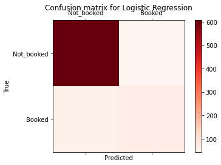

```python
%matplotlib inline

# Confusion matrix, accuracy, precison and recall for random forest and logistic regression
confusion_matrices = [
    ("Logistic Regression", confusion_matrix(model_test_y, best_RF_model.predict(model_test_x))),
    #("Logistic Regression", confusion_matrix(yc_test,best_LR_model.predict(Xc_test))),
]

draw_confusion_matrices(confusion_matrices)
```

#### ROC & AUC

```python
from sklearn.metrics import roc_curve
from sklearn import metrics

# Use predict_proba to get the probability results of Random Forest
y_pred_rf = best_RF_model.predict_proba(model_test_x)[:, 1]
fpr_rf, tpr_rf, _ = roc_curve(model_test_y, y_pred_rf)
```

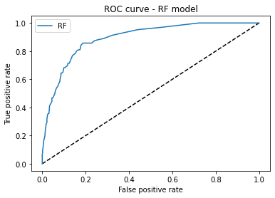

```python
# ROC curve of Random Forest result
plt.figure(1)
plt.plot([0, 1], [0, 1], 'k--')
plt.plot(fpr_rf, tpr_rf, label='RF')
plt.xlabel('False positive rate')
plt.ylabel('True positive rate')
plt.title('ROC curve - RF model')
plt.legend(loc='best')
plt.show()
```

```python
from sklearn import metrics

# AUC score
metrics.auc(fpr_rf,tpr_rf)
```

```
0.8923809523809524
```

### Feature selection

```python
# check feature importance of random forest for feature selection
forest = best_RF_model
forest.fit(model_train_x, model_train_y)

importances = forest.feature_importances_

# Print the feature ranking
print("Feature importance ranking by Random Forest Model:")
for k,v in sorted(zip(map(lambda x: round(x, 4), importances), model_train_x.columns), reverse=True):
    print (v + ": " + str(k))
```

```
Feature importance ranking by Random Forest Model:
total_interactions: 0.4806
message_length: 0.1181
lead_time: 0.0965
accept_t: 0.0936
total_reviews: 0.0772
days_of_stay: 0.0728
guest_size: 0.0444
past_booker: 0.0169
```

```
<sklearn.inspection._partial_dependence.PartialDependenceDisplay at 0x7f033c945c50>
```

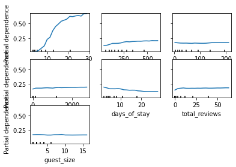

```python
from sklearn.inspection import plot_partial_dependence

features = ['total_interactions', 'message_length', 'lead_time', 'accept_t', 'days_of_stay', 'total_reviews','guest_size']
plot_partial_dependence(best_RF_model, model_train_x, features,
                        n_jobs=4, grid_resolution=20)
```

Interactions, message_length, accept_t, lead_time, days_of_stay, and reviews are the important features according to RF model results

## Logistic regression (numerical)

```python
# Check what features are included
accepted_inquiries = accepted_inquiries_df.copy()
accepted_inquiries = accepted_inquiries.drop(columns=['Unnamed: 0'])

accepted_inquiries.info()
```

```
<class 'pandas.core.frame.DataFrame'>
RangeIndex: 5169 entries, 0 to 5168
Data columns (total 9 columns):
 #   Column              Non-Null Count  Dtype
---  ------              --------------  -----
 0   guest_size          5169 non-null   float64
 1   total_interactions  5169 non-null   int64
 2   message_length      5169 non-null   float64
 3   total_reviews       5169 non-null   float64
 4   lead_time           5169 non-null   int64
 5   days_of_stay        5169 non-null   int64
 6   accept_t            5169 non-null   float64
 7   booked              5169 non-null   int64
 8   past_booker         5169 non-null   int64
dtypes: float64(4), int64(5)
memory usage: 363.6 KB
```

### Feature Preprocessing

#### Interaction features

```python
accepted_inquiries['interaction*message_length'] = accepted_inquiries['total_interactions'] * accepted_inquiries['message_length']
accepted_inquiries['interaction*lead_time'] = accepted_inquiries['total_interactions'] * accepted_inquiries['lead_time']
accepted_inquiries['interaction*days_of_stay'] = accepted_inquiries['total_interactions'] * accepted_inquiries['days_of_stay']
accepted_inquiries['interaction*past_booker'] = accepted_inquiries['total_interactions'] * accepted_inquiries['past_booker']

accepted_inquiries['message_length*lead_time'] = accepted_inquiries['message_length'] * accepted_inquiries['lead_time']
accepted_inquiries['message_length*days_of_stay'] = accepted_inquiries['message_length'] * accepted_inquiries['days_of_stay']

accepted_inquiries.info()
```

```
<class 'pandas.core.frame.DataFrame'>
RangeIndex: 5169 entries, 0 to 5168
Data columns (total 15 columns):
 #   Column                       Non-Null Count  Dtype
---  ------                       --------------  -----
 0   guest_size                   5169 non-null   float64
 1   total_interactions           5169 non-null   int64
 2   message_length               5169 non-null   float64
 3   total_reviews                5169 non-null   float64
 4   lead_time                    5169 non-null   int64
 5   days_of_stay                 5169 non-null   int64
 6   accept_t                     5169 non-null   float64
 7   booked                       5169 non-null   int64
 8   past_booker                  5169 non-null   int64
 9   interaction*message_length   5169 non-null   float64
 10  interaction*lead_time        5169 non-null   int64
 11  interaction*days_of_stay     5169 non-null   int64
 12  interaction*past_booker      5169 non-null   int64
 13  message_length*lead_time     5169 non-null   float64
 14  message_length*days_of_stay  5169 non-null   float64
dtypes: float64(7), int64(8)
memory usage: 605.9 KB
```

#### Feature scaling

```python
from sklearn import preprocessing

scale_list = list(accepted_inquiries.columns)
scale_list.remove('booked')
scale_list.remove('past_booker')

# MinMax scaling
sc_scale = preprocessing.MinMaxScaler().fit(accepted_inquiries[scale_list])
accepted_inquiries[scale_list] = sc_scale.transform(accepted_inquiries[scale_list])
```

```python
accepted_inquiries.head(10)
```

|  | guest_size | total_interactions | message_length | total_reviews | lead_time | days_of_stay | accept_t | booked | past_booker | interaction*message_length | interaction*lead_time | interaction*days_of_stay | interaction*past_booker | message_length*lead_time | message_length*days_of_stay |
| --- | --- | --- | --- | --- | --- | --- | --- | --- | --- | --- | --- | --- | --- | --- | --- |
| 0 | 0.067 | 0.008 | 0.106 | 0.063 | 0.026 | 0.003 | 0.000 | 0 | 0 | 0.011 | 0.003 | 0.000 | 0.000 | 0.011 | 0.002 |
| 1 | 0.333 | 0.039 | 0.015 | 0.000 | 0.083 | 0.020 | 0.016 | 0 | 1 | 0.004 | 0.024 | 0.005 | 0.054 | 0.005 | 0.001 |
| 2 | 0.200 | 0.023 | 0.036 | 0.000 | 0.019 | 0.011 | 0.006 | 0 | 0 | 0.006 | 0.004 | 0.002 | 0.000 | 0.003 | 0.002 |
| 3 | 0.333 | 0.039 | 0.217 | 0.060 | 0.010 | 0.020 | 0.000 | 0 | 0 | 0.052 | 0.003 | 0.005 | 0.000 | 0.009 | 0.017 |
| 4 | 0.000 | 0.008 | 0.047 | 0.004 | 0.041 | 0.497 | 0.000 | 0 | 0 | 0.005 | 0.005 | 0.051 | 0.000 | 0.008 | 0.084 |
| 5 | 0.200 | 0.039 | 0.102 | 0.011 | 0.265 | 0.017 | 0.000 | 0 | 0 | 0.025 | 0.075 | 0.004 | 0.000 | 0.108 | 0.007 |
| 6 | 0.067 | 0.039 | 0.102 | 0.052 | 0.167 | 0.056 | 0.000 | 0 | 1 | 0.025 | 0.047 | 0.014 | 0.054 | 0.067 | 0.021 |
| 7 | 0.067 | 0.031 | 0.360 | 0.201 | 0.286 | 0.170 | 0.002 | 0 | 0 | 0.075 | 0.069 | 0.035 | 0.000 | 0.411 | 0.225 |
| 8 | 1.000 | 0.000 | 0.053 | 0.000 | 0.012 | 0.006 | 0.000 | 0 | 0 | 0.004 | 0.001 | 0.000 | 0.000 | 0.003 | 0.002 |
| 9 | 0.200 | 0.008 | 0.188 | 0.007 | 0.252 | 0.014 | 0.000 | 0 | 1 | 0.019 | 0.030 | 0.002 | 0.023 | 0.188 | 0.011 |

#### Split training and test data

```python
from sklearn.model_selection import train_test_split

model_train, model_test = train_test_split(accepted_inquiries, test_size=0.15, random_state = 3)
model_train_x = model_train.drop(['booked'], axis = 1)
model_test_x = model_test.drop(['booked'], axis = 1)
model_train_y = model_train['booked']
model_test_y = model_test['booked']
```

### Train model and find optimal hypermarameters

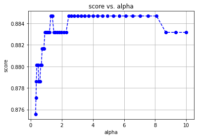

```
The optimaized alpha and score of Lasso linear is: 1.2949258422052625 ,0.8846737481031867
```

```python
from sklearn.model_selection import train_test_split
from sklearn.linear_model import LogisticRegression
from sklearn.metrics import mean_squared_error, r2_score
from math import sqrt

lr_train, lr_validate = train_test_split(model_train, test_size=0.15, random_state = 0)

lr_train_x = lr_train.drop(['booked'], axis = 1)
lr_validate_x = lr_validate.drop(['booked'], axis = 1)
lr_train_y = lr_train['booked']
lr_validate_y = lr_validate['booked']

alphas = np.logspace (-0.5, 1, num=50)
# alphas= [1, 5, 10]
scores = np.empty_like(alphas)
opt_a = float('-inf')
max_score = float('-inf')
for i, a in enumerate(alphas):
    lasso = LogisticRegression(penalty='l1', C=a, solver='liblinear')
    lasso.fit(lr_train_x, lr_train_y)
    scores[i] = lasso.score(lr_validate_x, lr_validate_y)
    if scores[i] > max_score:
        max_score = scores[i]
        opt_a = a
        lasso_save = lasso
plt.plot(alphas, scores, color='b', linestyle='dashed', marker='o',markerfacecolor='blue', markersize=6)
plt.xlabel('alpha')
plt.ylabel('score')
plt.grid(True)
plt.title('score vs. alpha')
plt.show()
print('The optimaized alpha and score of Lasso linear is: ' + str(opt_a) + " ," + str(max_score))
```

```python
# combine the validate data and training data, use the optimal alpha, re-train the model
best_LR_model = LogisticRegression(penalty='l1', C=opt_a, solver='liblinear')
best_LR_model.fit(model_train_x, model_train_y)
```

```
LogisticRegression(C=1.2949258422052625, class_weight=None, dual=False,
                   fit_intercept=True, intercept_scaling=1, l1_ratio=None,
                   max_iter=100, multi_class='auto', n_jobs=None, penalty='l1',
                   random_state=None, solver='liblinear', tol=0.0001, verbose=0,
                   warm_start=False)
```

### Model evaluation

#### Confusion matrix

```python
from sklearn.metrics import confusion_matrix
from sklearn.metrics import classification_report
from sklearn.metrics import precision_score
from sklearn.metrics import recall_score

# calculate accuracy, precision and recall, [[tn, fp],[]]
def cal_evaluation(classifier, cm):
    tn = cm[0][0]
    fp = cm[0][1]
    fn = cm[1][0]
    tp = cm[1][1]
    accuracy  = (tp + tn) / (tp + fp + fn + tn + 0.0)
    precision = tp / (tp + fp + 0.0)
    recall = tp / (tp + fn + 0.0)
    print (classifier)
    print ("Accuracy is: %0.3f" % accuracy)
    print ("precision is: %0.3f" % precision)
    print ("recall is: %0.3f" % recall)

# print out confusion matrices
def draw_confusion_matrices(confusion_matricies):
    class_names = ['Not_booked','Booked']
    for cm in confusion_matrices:
        classifier, cm = cm[0], cm[1]
        cal_evaluation(classifier, cm)
        fig = plt.figure()
        ax = fig.add_subplot(111)
        cax = ax.matshow(cm, interpolation='nearest',cmap=plt.get_cmap('Reds'))
        plt.title('Confusion matrix for %s' % classifier)
        fig.colorbar(cax)
        ax.set_xticklabels([''] + class_names)
        ax.set_yticklabels([''] + class_names)
        plt.xlabel('Predicted')
        plt.ylabel('True')
        plt.show()
```

```python
confusion_matrix(model_test_y, best_LR_model.predict(model_test_x))
```

```
array([[624,  26],
       [ 82,  44]])
```

```
Logistic Regression
Accuracy is: 0.861
precision is: 0.629
recall is: 0.349
```

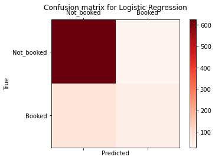

```python
%matplotlib inline

# Confusion matrix, accuracy, precison and recall for random forest and logistic regression
confusion_matrices = [
    ("Logistic Regression", confusion_matrix(model_test_y, best_LR_model.predict(model_test_x))),
]

draw_confusion_matrices(confusion_matrices)
```

#### ROC & AUC

```python
from sklearn.metrics import roc_curve
from sklearn import metrics

# Use predict_proba to get the probability results of Logistic Regression
y_pred_lr = best_LR_model.predict_proba(model_test_x)[:, 1]
fpr_lr, tpr_lr, _ = roc_curve(model_test_y, y_pred_lr)
```

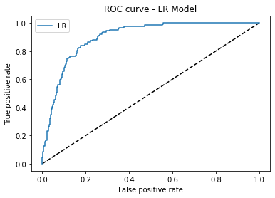

```python
# ROC Curve
plt.figure(1)
plt.plot([0, 1], [0, 1], 'k--')
plt.plot(fpr_lr, tpr_lr, label='LR')
plt.xlabel('False positive rate')
plt.ylabel('True positive rate')
plt.title('ROC curve - LR Model')
plt.legend(loc='best')
plt.show()
```

```python
# AUC score
metrics.auc(fpr_lr,tpr_lr)
```

```
0.8996825396825396
```

### Feature selection

```python
# Store the coef for feature selection
res = pd.DataFrame(columns=['Feature', 'Coef'])

for k,v in sorted(zip(map(lambda x: round(x, 4), best_LR_model.fit(model_train_x, model_train_y).coef_[0]), \
                      model_train_x.columns), key=lambda k_v:(-abs(k_v[0]),k_v[1])):
    print (v + ": " + str(k))
    res = res.append({'Feature': v, 'Coef': k}, ignore_index=True)
```

```
total_interactions: 12.3551
interaction*message_length: 11.4608
message_length*days_of_stay: -9.8243
days_of_stay: -7.4365
interaction*lead_time: 4.1926
interaction*past_booker: 2.8028
lead_time: -2.0409
total_reviews: 1.224
guest_size: -0.806
message_length*lead_time: -0.7779
past_booker: 0.3819
accept_t: 0.1495
interaction*days_of_stay: 0.0
message_length: 0.0
```

Interactions, days_of_stay, reviews, lead_time, accept_t, guest_size, user_stage are important features according to logistic regression models with numerical features.

## Logistic regression (binned numerical)

```python
# Check what features are included
accepted_inquiries = accepted_inquiries_df.copy()
accepted_inquiries = accepted_inquiries.drop(columns=['Unnamed: 0'])

accepted_inquiries.info()
```

```
<class 'pandas.core.frame.DataFrame'>
RangeIndex: 5169 entries, 0 to 5168
Data columns (total 9 columns):
 #   Column              Non-Null Count  Dtype
---  ------              --------------  -----
 0   guest_size          5169 non-null   float64
 1   total_interactions  5169 non-null   int64
 2   message_length      5169 non-null   float64
 3   total_reviews       5169 non-null   float64
 4   lead_time           5169 non-null   int64
 5   days_of_stay        5169 non-null   int64
 6   accept_t            5169 non-null   float64
 7   booked              5169 non-null   int64
 8   past_booker         5169 non-null   int64
dtypes: float64(4), int64(5)
memory usage: 363.6 KB
```

### Feature Preprocessing

#### Feature encoding

In order to see the nuances of some features' impact, I decided to create buckets for numerical variables including:

- Interaction
- Review
- Lead time
- Days of stay
- Message length
- Guest size

And these bins will be used to create interactive features as well

```python
# Binning interactions
interaction = [0,10,20,30,1000]
interaction_range = ['1-10','11-20','21-30','>30']
interactions_bin = pd.cut(accepted_inquiries['total_interactions'], bins = interaction, labels= interaction_range)
accepted_inquiries['interactions'] = interactions_bin

# Binning reviews
review = [-1,0,10,20,30,1000]
review_range = ['0','1-10','11-20','21-30','>30']
reviews_bin = pd.cut(accepted_inquiries['total_reviews'], bins = review, labels=review_range)
accepted_inquiries['reviews'] = reviews_bin

# Binning lead time
lead = [-1,30,60,90,1000]
lead_range = ['1-30d','31-60d','61-90d', '>90d']
lead_bin = pd.cut(accepted_inquiries['lead_time'], bins = lead, labels=lead_range)
accepted_inquiries['lead_time'] = lead_bin

# Binning days_of_stay
stay = [-1,5,10,15,1000]
stay_range = ['1-5d','6-10d','11-15d','>15d']
stay_bin = pd.cut(accepted_inquiries['days_of_stay'], bins = stay, labels=stay_range)
accepted_inquiries['days_of_stay'] = stay_bin

# Binning message_length
length = [-1,150,300,450,3000]
length_range = ['0-150','151-300','301-450','>450']
length_bin = pd.cut(accepted_inquiries['message_length'], bins = length, labels=length_range)
accepted_inquiries['message_length'] = length_bin

# Binning guest size
size = [-1,1,2,4,6,30]
size_range = ['1','2','3-4','5-6','>6']
size_bin = pd.cut(accepted_inquiries['guest_size'], bins = size, labels=size_range)
accepted_inquiries['guest_size'] = size_bin
```

```python
# generate binary values using get_dummies
accepted_inquiries = pd.get_dummies(accepted_inquiries, columns=["interactions", "reviews", "lead_time", "days_of_stay", "message_length", "guest_size"] )
```

```python
# Drop columns not to be used
accepted_inquiries = accepted_inquiries.drop(['total_interactions', 'total_reviews'], axis = 1)
```

```python
accepted_inquiries.info()
```

```
<class 'pandas.core.frame.DataFrame'>
RangeIndex: 5169 entries, 0 to 5168
Data columns (total 29 columns):
 #   Column                  Non-Null Count  Dtype
---  ------                  --------------  -----
 0   accept_t                5169 non-null   float64
 1   booked                  5169 non-null   int64
 2   past_booker             5169 non-null   int64
 3   interactions_1-10       5169 non-null   uint8
 4   interactions_11-20      5169 non-null   uint8
 5   interactions_21-30      5169 non-null   uint8
 6   interactions_>30        5169 non-null   uint8
 7   reviews_0               5169 non-null   uint8
 8   reviews_1-10            5169 non-null   uint8
 9   reviews_11-20           5169 non-null   uint8
```

[output cut: 21 more lines]

#### Interaction features

Creat interaction features to discover combined effects of independent variables

```python
# Interaction features

interactions = accepted_inquiries.columns[3:7]
reviews = accepted_inquiries.columns[7:12]
lead_times = accepted_inquiries.columns[12:16]
stays = accepted_inquiries.columns[16:20]
message_lengths = accepted_inquiries.columns[20:24]
guest_sizes = accepted_inquiries.columns[24:29]

# Interaction * message length
for i in interactions:
  for j in message_lengths:
    accepted_inquiries[i+'*'+j] = accepted_inquiries[i] * accepted_inquiries[j]

# Interaction * lead time
for i in interactions:
  for j in lead_times:
    accepted_inquiries[i+'*'+j] = accepted_inquiries[i] * accepted_inquiries[j]

# Interaction * days of stay
for i in interactions:
  for j in stays:
    accepted_inquiries[i+'*'+j] = accepted_inquiries[i] * accepted_inquiries[j]

# User stage + interactions
for i in interactions:
    accepted_inquiries['past_booker'+'*'+i] = accepted_inquiries['past_booker'] * accepted_inquiries[i]

# Message length * days of stay
for i in message_lengths:
  for j in stays:
    accepted_inquiries[i+'*'+j] = accepted_inquiries[i] * accepted_inquiries[j]

# Message length * lead time
for i in message_lengths:
  for j in lead_times:
    accepted_inquiries[i+'*'+j] = accepted_inquiries[i] * accepted_inquiries[j]
```

```python
accepted_inquiries.head(10)
```

|  | accept_t | booked | past_booker | interactions_1-10 | interactions_11-20 | interactions_21-30 | interactions_>30 | reviews_0 | reviews_1-10 | reviews_11-20 | reviews_21-30 | reviews_>30 | lead_time_1-30d | lead_time_31-60d | lead_time_61-90d | lead_time_>90d | days_of_stay_1-5d | days_of_stay_6-10d | days_of_stay_11-15d | days_of_stay_>15d | message_length_0-150 | message_length_151-300 | message_length_301-450 | message_length_>450 | guest_size_1 | guest_size_2 | guest_size_3-4 | guest_size_5-6 | guest_size_>6 | … |
| --- | --- | --- | --- | --- | --- | --- | --- | --- | --- | --- | --- | --- | --- | --- | --- | --- | --- | --- | --- | --- | --- | --- | --- | --- | --- | --- | --- | --- | --- | --- |
| 0 | 0.000 | 0 | 0 | 1 | 0 | 0 | 0 | 0 | 0 | 1 | 0 | 0 | 1 | 0 | 0 | 0 | 1 | 0 | 0 | 0 | 0 | 1 | 0 | 0 | 0 | 1 | 0 | 0 | 0 | … |
| 1 | 3379.417 | 0 | 1 | 1 | 0 | 0 | 0 | 1 | 0 | 0 | 0 | 0 | 0 | 0 | 1 | 0 | 0 | 1 | 0 | 0 | 1 | 0 | 0 | 0 | 0 | 0 | 0 | 1 | 0 | … |
| 2 | 1311.383 | 0 | 0 | 1 | 0 | 0 | 0 | 1 | 0 | 0 | 0 | 0 | 1 | 0 | 0 | 0 | 1 | 0 | 0 | 0 | 1 | 0 | 0 | 0 | 0 | 0 | 1 | 0 | 0 | … |
| 3 | 0.267 | 0 | 0 | 1 | 0 | 0 | 0 | 0 | 0 | 1 | 0 | 0 | 1 | 0 | 0 | 0 | 0 | 1 | 0 | 0 | 0 | 0 | 1 | 0 | 0 | 0 | 0 | 1 | 0 | … |
| 4 | 0.000 | 0 | 0 | 1 | 0 | 0 | 0 | 0 | 1 | 0 | 0 | 0 | 0 | 1 | 0 | 0 | 0 | 0 | 0 | 1 | 1 | 0 | 0 | 0 | 1 | 0 | 0 | 0 | 0 | … |
| 5 | 0.250 | 0 | 0 | 1 | 0 | 0 | 0 | 0 | 1 | 0 | 0 | 0 | 0 | 0 | 0 | 1 | 0 | 1 | 0 | 0 | 0 | 1 | 0 | 0 | 0 | 0 | 1 | 0 | 0 | … |
| 6 | 1.583 | 0 | 1 | 1 | 0 | 0 | 0 | 0 | 0 | 1 | 0 | 0 | 0 | 0 | 0 | 1 | 0 | 0 | 0 | 1 | 0 | 1 | 0 | 0 | 0 | 1 | 0 | 0 | 0 | … |
| 7 | 455.417 | 0 | 0 | 1 | 0 | 0 | 0 | 0 | 0 | 0 | 0 | 1 | 0 | 0 | 0 | 1 | 0 | 0 | 0 | 1 | 0 | 0 | 0 | 1 | 0 | 1 | 0 | 0 | 0 | … |
| 8 | 0.000 | 0 | 0 | 1 | 0 | 0 | 0 | 1 | 0 | 0 | 0 | 0 | 1 | 0 | 0 | 0 | 1 | 0 | 0 | 0 | 1 | 0 | 0 | 0 | 0 | 0 | 0 | 0 | 1 | … |
| 9 | 0.167 | 0 | 1 | 1 | 0 | 0 | 0 | 0 | 1 | 0 | 0 | 0 | 0 | 0 | 0 | 1 | 0 | 1 | 0 | 0 | 0 | 0 | 1 | 0 | 0 | 0 | 1 | 0 | 0 | … |

10 rows × 113 columns

#### Feature scaling

```python
# Scale accept_t (MinMax scaling)
sc_scale = preprocessing.MinMaxScaler().fit(accepted_inquiries[['accept_t']])
accepted_inquiries[['accept_t']] = sc_scale.transform(accepted_inquiries[['accept_t']])
```

```python
accepted_inquiries.head(10)
```

|  | accept_t | booked | past_booker | interactions_1-10 | interactions_11-20 | interactions_21-30 | interactions_>30 | reviews_0 | reviews_1-10 | reviews_11-20 | reviews_21-30 | reviews_>30 | lead_time_1-30d | lead_time_31-60d | lead_time_61-90d | lead_time_>90d | days_of_stay_1-5d | days_of_stay_6-10d | days_of_stay_11-15d | days_of_stay_>15d | message_length_0-150 | message_length_151-300 | message_length_301-450 | message_length_>450 | guest_size_1 | guest_size_2 | guest_size_3-4 | guest_size_5-6 | guest_size_>6 | … |
| --- | --- | --- | --- | --- | --- | --- | --- | --- | --- | --- | --- | --- | --- | --- | --- | --- | --- | --- | --- | --- | --- | --- | --- | --- | --- | --- | --- | --- | --- | --- |
| 0 | 0.000 | 0 | 0 | 1 | 0 | 0 | 0 | 0 | 0 | 1 | 0 | 0 | 1 | 0 | 0 | 0 | 1 | 0 | 0 | 0 | 0 | 1 | 0 | 0 | 0 | 1 | 0 | 0 | 0 | … |
| 1 | 0.016 | 0 | 1 | 1 | 0 | 0 | 0 | 1 | 0 | 0 | 0 | 0 | 0 | 0 | 1 | 0 | 0 | 1 | 0 | 0 | 1 | 0 | 0 | 0 | 0 | 0 | 0 | 1 | 0 | … |
| 2 | 0.006 | 0 | 0 | 1 | 0 | 0 | 0 | 1 | 0 | 0 | 0 | 0 | 1 | 0 | 0 | 0 | 1 | 0 | 0 | 0 | 1 | 0 | 0 | 0 | 0 | 0 | 1 | 0 | 0 | … |
| 3 | 0.000 | 0 | 0 | 1 | 0 | 0 | 0 | 0 | 0 | 1 | 0 | 0 | 1 | 0 | 0 | 0 | 0 | 1 | 0 | 0 | 0 | 0 | 1 | 0 | 0 | 0 | 0 | 1 | 0 | … |
| 4 | 0.000 | 0 | 0 | 1 | 0 | 0 | 0 | 0 | 1 | 0 | 0 | 0 | 0 | 1 | 0 | 0 | 0 | 0 | 0 | 1 | 1 | 0 | 0 | 0 | 1 | 0 | 0 | 0 | 0 | … |
| 5 | 0.000 | 0 | 0 | 1 | 0 | 0 | 0 | 0 | 1 | 0 | 0 | 0 | 0 | 0 | 0 | 1 | 0 | 1 | 0 | 0 | 0 | 1 | 0 | 0 | 0 | 0 | 1 | 0 | 0 | … |
| 6 | 0.000 | 0 | 1 | 1 | 0 | 0 | 0 | 0 | 0 | 1 | 0 | 0 | 0 | 0 | 0 | 1 | 0 | 0 | 0 | 1 | 0 | 1 | 0 | 0 | 0 | 1 | 0 | 0 | 0 | … |
| 7 | 0.002 | 0 | 0 | 1 | 0 | 0 | 0 | 0 | 0 | 0 | 0 | 1 | 0 | 0 | 0 | 1 | 0 | 0 | 0 | 1 | 0 | 0 | 0 | 1 | 0 | 1 | 0 | 0 | 0 | … |
| 8 | 0.000 | 0 | 0 | 1 | 0 | 0 | 0 | 1 | 0 | 0 | 0 | 0 | 1 | 0 | 0 | 0 | 1 | 0 | 0 | 0 | 1 | 0 | 0 | 0 | 0 | 0 | 0 | 0 | 1 | … |
| 9 | 0.000 | 0 | 1 | 1 | 0 | 0 | 0 | 0 | 1 | 0 | 0 | 0 | 0 | 0 | 0 | 1 | 0 | 1 | 0 | 0 | 0 | 0 | 1 | 0 | 0 | 0 | 1 | 0 | 0 | … |

10 rows × 113 columns

#### Split training and test data

```python
from sklearn.model_selection import train_test_split

model_train, model_test = train_test_split(accepted_inquiries, test_size=0.15, random_state = 3)
model_train_x = model_train.drop(['booked'], axis = 1)
model_test_x = model_test.drop(['booked'], axis = 1)
model_train_y = model_train['booked']
model_test_y = model_test['booked']
```

### Train model and find optimal hypermarameters

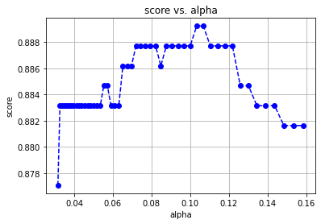

```
The optimaized alpha and score of Lasso linear is: 0.1033441063880556 ,0.8892261001517451
```

```python
from sklearn.model_selection import train_test_split
from sklearn.linear_model import LogisticRegression
from sklearn.metrics import mean_squared_error, r2_score
from math import sqrt

lr_train, lr_validate = train_test_split(model_train, test_size=0.15, random_state = 0)

lr_train_x = lr_train.drop(['booked'], axis = 1)
lr_validate_x = lr_validate.drop(['booked'], axis = 1)
lr_train_y = lr_train['booked']
lr_validate_y = lr_validate['booked']

alphas = np.logspace (-1.5, -0.8, num=50)
# alphas= [1, 5, 10]
scores = np.empty_like(alphas)
opt_a = float('-inf')
max_score = float('-inf')
for i, a in enumerate(alphas):
    lasso = LogisticRegression(penalty='l1', C=a, solver='liblinear')
    lasso.fit(lr_train_x, lr_train_y)
    scores[i] = lasso.score(lr_validate_x, lr_validate_y)
    if scores[i] > max_score:
        max_score = scores[i]
        opt_a = a
        lasso_save = lasso
plt.plot(alphas, scores, color='b', linestyle='dashed', marker='o',markerfacecolor='blue', markersize=6)
plt.xlabel('alpha')
plt.ylabel('score')
plt.grid(True)
plt.title('score vs. alpha')
plt.show()
print('The optimaized alpha and score of Lasso linear is: ' + str(opt_a) + " ," + str(max_score))
```

```python
# combine the validate data and training data, use the optimal alpha, re-train the model
best_LR_model = LogisticRegression(penalty='l1', C=opt_a, solver='liblinear')
best_LR_model.fit(model_train_x, model_train_y)
```

```
LogisticRegression(C=0.1033441063880556, class_weight=None, dual=False,
                   fit_intercept=True, intercept_scaling=1, l1_ratio=None,
                   max_iter=100, multi_class='auto', n_jobs=None, penalty='l1',
                   random_state=None, solver='liblinear', tol=0.0001, verbose=0,
                   warm_start=False)
```

### Model evaluation

#### Confusion matrix

```python
from sklearn.metrics import confusion_matrix
from sklearn.metrics import classification_report
from sklearn.metrics import precision_score
from sklearn.metrics import recall_score

# calculate accuracy, precision and recall, [[tn, fp],[]]
def cal_evaluation(classifier, cm):
    tn = cm[0][0]
    fp = cm[0][1]
    fn = cm[1][0]
    tp = cm[1][1]
    accuracy  = (tp + tn) / (tp + fp + fn + tn + 0.0)
    precision = tp / (tp + fp + 0.0)
    recall = tp / (tp + fn + 0.0)
    print (classifier)
    print ("Accuracy is: %0.3f" % accuracy)
    print ("precision is: %0.3f" % precision)
    print ("recall is: %0.3f" % recall)

# print out confusion matrices
def draw_confusion_matrices(confusion_matricies):
    class_names = ['Not_booked','Booked']
    for cm in confusion_matrices:
        classifier, cm = cm[0], cm[1]
        cal_evaluation(classifier, cm)
        fig = plt.figure()
        ax = fig.add_subplot(111)
        cax = ax.matshow(cm, interpolation='nearest',cmap=plt.get_cmap('Reds'))
        plt.title('Confusion matrix for %s' % classifier)
        fig.colorbar(cax)
        ax.set_xticklabels([''] + class_names)
        ax.set_yticklabels([''] + class_names)
        plt.xlabel('Predicted')
        plt.ylabel('True')
        plt.show()
```

```python
confusion_matrix(model_test_y, best_LR_model.predict(model_test_x))
```

```
array([[594,  56],
       [ 51,  75]])
```

```
Logistic Regression
Accuracy is: 0.862
precision is: 0.573
recall is: 0.595
```

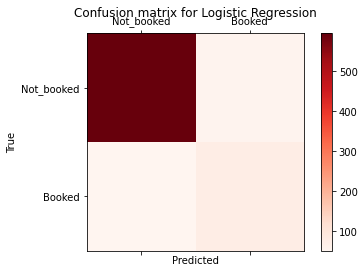

```python
%matplotlib inline

# Confusion matrix, accuracy, precison and recall for random forest and logistic regression
confusion_matrices = [
    ("Logistic Regression", confusion_matrix(model_test_y, best_LR_model.predict(model_test_x))),
    #("Logistic Regression", confusion_matrix(yc_test,best_LR_model.predict(Xc_test))),
]

draw_confusion_matrices(confusion_matrices)
```

#### ROC & AUC

```python
from sklearn.metrics import roc_curve
from sklearn import metrics

# Use predict_proba to get the probability results of Logistic Regression
y_pred_lr = best_LR_model.predict_proba(model_test_x)[:, 1]
fpr_lr, tpr_lr, _ = roc_curve(model_test_y, y_pred_lr)
```

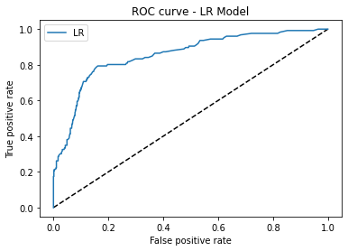

```python
# ROC Curve
plt.figure(1)
plt.plot([0, 1], [0, 1], 'k--')
plt.plot(fpr_lr, tpr_lr, label='LR')
plt.xlabel('False positive rate')
plt.ylabel('True positive rate')
plt.title('ROC curve - LR Model')
plt.legend(loc='best')
plt.show()
```

```python
# AUC score
metrics.auc(fpr_lr,tpr_lr)
```

```
0.855030525030525
```

### Feature selection

```python
# Store the coef for feature selection
res = pd.DataFrame(columns=['Feature', 'Coef'])

for k,v in sorted(zip(map(lambda x: round(x, 4), best_LR_model.fit(model_train_x, model_train_y).coef_[0]), \
                      model_train_x.columns), key=lambda k_v:(-abs(k_v[0]),k_v[1])):
    print (v + ": " + str(k))
    res = res.append({'Feature': v, 'Coef': k}, ignore_index=True)
```

```
interactions_1-10: -3.0269
interactions_>30: 1.1172
interactions_21-30: 0.7208
days_of_stay_>15d: -0.6241
message_length_0-150: -0.5969
past_booker: 0.5439
reviews_0: -0.3498
days_of_stay_1-5d: 0.1486
message_length_>450: 0.1066
guest_size_2: 0.07
interactions_11-20*days_of_stay_>15d: -0.0471
message_length_151-300: -0.0382
guest_size_5-6: -0.0377
message_length_151-300*lead_time_1-30d: -0.0179
message_length_301-450: 0.0127
interactions_11-20*message_length_0-150: -0.0093
accept_t: 0.0
days_of_stay_11-15d: 0.0
days_of_stay_6-10d: 0.0
guest_size_1: 0.0
guest_size_3-4: 0.0
guest_size_>6: 0.0
interactions_1-10*days_of_stay_1-5d: 0.0
interactions_1-10*days_of_stay_11-15d: 0.0
interactions_1-10*days_of_stay_6-10d: 0.0
interactions_1-10*days_of_stay_>15d: 0.0
interactions_1-10*lead_time_1-30d: 0.0
interactions_1-10*lead_time_31-60d: 0.0
interactions_1-10*lead_time_61-90d: 0.0
interactions_1-10*lead_time_>90d: 0.0
interactions_1-10*message_length_0-150: 0.0
interactions_1-10*message_length_151-300: 0.0
interactions_1-10*message_length_301-450: 0.0
interactions_1-10*message_length_>450: 0.0
interactions_11-20: 0.0
interactions_11-20*days_of_stay_1-5d: 0.0
interactions_11-20*days_of_stay_11-15d: 0.0
interactions_11-20*days_of_stay_6-10d: 0.0
interactions_11-20*lead_time_1-30d: 0.0
interactions_11-20*lead_time_31-60d: 0.0
```

[output cut: 57 more lines]

```
message_length_>450*days_of_stay_11-15d: 0.0
message_length_>450*days_of_stay_6-10d: 0.0
message_length_>450*days_of_stay_>15d: 0.0
message_length_>450*lead_time_1-30d: 0.0
message_length_>450*lead_time_31-60d: 0.0
message_length_>450*lead_time_61-90d: 0.0
message_length_>450*lead_time_>90d: 0.0
past_booker*interactions_1-10: 0.0
past_booker*interactions_11-20: 0.0
past_booker*interactions_21-30: 0.0
past_booker*interactions_>30: 0.0
reviews_1-10: 0.0
reviews_11-20: 0.0
reviews_21-30: 0.0
reviews_>30: 0.0
```

interactions, days_of_stay, reviews, user_stage, message length, guest_size are the most important features according to logistic regression model for binned numerical features

## Final model (logistic regression with binned important features )

- RF model results: **Interactions**, message_length, **accept_t**, lead_time, **days_of_stay**, and **reviews** are the most important features
- Logistic regression model with numerical features: **Interactions**, **days_of_stay**, **reviews**, **lead_time**, **accept_t**, guest_size, and **user_stage** are important features
- Logistic regression model fore binned numerical features:: **interactions**, **days_of_stay**, **reviews**, and **user_stage** are the most important features

Logistic regression model with numerical features has the best performance(AUC score: 0.90), but in order to see the interactions between features more clearly, I would still use logistic regression model with binned numerical features(AUC score: 0.86) as the final model

```python
# Check what features are included
accepted_inquiries = accepted_inquiries_df.copy() # 'lead_time'
accepted_inquiries = accepted_inquiries[['total_interactions', 'total_reviews', 'days_of_stay', 'accept_t', 'past_booker', 'booked']]

accepted_inquiries.info()
```

```
<class 'pandas.core.frame.DataFrame'>
RangeIndex: 5169 entries, 0 to 5168
Data columns (total 6 columns):
 #   Column              Non-Null Count  Dtype
---  ------              --------------  -----
 0   total_interactions  5169 non-null   int64
 1   total_reviews       5169 non-null   float64
 2   days_of_stay        5169 non-null   int64
 3   accept_t            5169 non-null   float64
 4   past_booker         5169 non-null   int64
 5   booked              5169 non-null   int64
dtypes: float64(2), int64(4)
memory usage: 242.4 KB
```

### Feature Preprocessing

#### Feature encoding

```python
# Binning interactions
interaction = [0,10,20,30,1000]
interaction_range = ['1-10','11-20','21-30','>30']
interactions_bin = pd.cut(accepted_inquiries['total_interactions'], bins = interaction, labels= interaction_range)
accepted_inquiries['interactions'] = interactions_bin

# Binning reviews
review = [-1,0,10,20,30,1000]
review_range = ['0','1-10','11-20','21-30','>30']
reviews_bin = pd.cut(accepted_inquiries['total_reviews'], bins = review, labels=review_range)
accepted_inquiries['reviews'] = reviews_bin

# Binning lead time
# lead = [-1,30,60,90,1000]
# lead_range = ['1-30d','31-60d','61-90d', '>90d']
# lead_bin = pd.cut(accepted_inquiries['lead_time'], bins = lead, labels=lead_range)
# accepted_inquiries['lead_time'] = lead_bin

# Binning days_of_stay
stay = [-1,5,10,15,1000]
stay_range = ['1-5d','6-10d','11-15d','>15d']
stay_bin = pd.cut(accepted_inquiries['days_of_stay'], bins = stay, labels=stay_range)
accepted_inquiries['days_of_stay'] = stay_bin
```

```python
# generate binary values using get_dummies # "lead_time",
accepted_inquiries = pd.get_dummies(accepted_inquiries, columns=["interactions", "reviews",  "days_of_stay"] )
```

```python
# Drop columns not to be used
accepted_inquiries = accepted_inquiries.drop(['total_interactions', 'total_reviews'], axis = 1)
```

```python
accepted_inquiries.info()
```

```
<class 'pandas.core.frame.DataFrame'>
RangeIndex: 5169 entries, 0 to 5168
Data columns (total 16 columns):
 #   Column               Non-Null Count  Dtype
---  ------               --------------  -----
 0   accept_t             5169 non-null   float64
 1   past_booker          5169 non-null   int64
 2   booked               5169 non-null   int64
 3   interactions_1-10    5169 non-null   uint8
 4   interactions_11-20   5169 non-null   uint8
 5   interactions_21-30   5169 non-null   uint8
 6   interactions_>30     5169 non-null   uint8
 7   reviews_0            5169 non-null   uint8
 8   reviews_1-10         5169 non-null   uint8
 9   reviews_11-20        5169 non-null   uint8
 10  reviews_21-30        5169 non-null   uint8
 11  reviews_>30          5169 non-null   uint8
 12  days_of_stay_1-5d    5169 non-null   uint8
 13  days_of_stay_6-10d   5169 non-null   uint8
 14  days_of_stay_11-15d  5169 non-null   uint8
 15  days_of_stay_>15d    5169 non-null   uint8
dtypes: float64(1), int64(2), uint8(13)
memory usage: 186.9 KB
```

#### Interaction features

Creat interaction features to discover combined effects of independent variables

```python
# Interaction features

interactions = accepted_inquiries.columns[3:7]
reviews = accepted_inquiries.columns[7:12]
stays = accepted_inquiries.columns[12:16]


# Interaction * days of stay
for i in interactions:
  for j in stays:
    accepted_inquiries[i+'*'+j] = accepted_inquiries[i] * accepted_inquiries[j]

# User stage + interactions
for i in interactions:
    accepted_inquiries['past_booker'+'*'+i] = accepted_inquiries['past_booker'] * accepted_inquiries[i]
```

```python
accepted_inquiries.info()
```

```
<class 'pandas.core.frame.DataFrame'>
RangeIndex: 5169 entries, 0 to 5168
Data columns (total 36 columns):
 #   Column                                  Non-Null Count  Dtype
---  ------                                  --------------  -----
 0   accept_t                                5169 non-null   float64
 1   past_booker                             5169 non-null   int64
 2   booked                                  5169 non-null   int64
 3   interactions_1-10                       5169 non-null   uint8
 4   interactions_11-20                      5169 non-null   uint8
 5   interactions_21-30                      5169 non-null   uint8
 6   interactions_>30                        5169 non-null   uint8
 7   reviews_0                               5169 non-null   uint8
 8   reviews_1-10                            5169 non-null   uint8
 9   reviews_11-20                           5169 non-null   uint8
```

[output cut: 28 more lines]

#### Feature scaling

```python
# Scale accept_t (MinMax scaling)
sc_scale = preprocessing.MinMaxScaler().fit(accepted_inquiries[['accept_t']])
accepted_inquiries[['accept_t']] = sc_scale.transform(accepted_inquiries[['accept_t']])
```

#### Split training and test data

```python
from sklearn.model_selection import train_test_split

model_train, model_test = train_test_split(accepted_inquiries, test_size=0.15, random_state = 3)
model_train_x = model_train.drop(['booked'], axis = 1)
model_test_x = model_test.drop(['booked'], axis = 1)
model_train_y = model_train['booked']
model_test_y = model_test['booked']
```

### Train model and find optimal hypermarameters

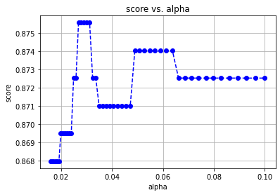

```
The optimaized alpha and score of Ridge linear is: 0.02682695795279726 ,0.8755690440060698
```

```python
from sklearn.model_selection import train_test_split
from sklearn.linear_model import LogisticRegression
from sklearn.metrics import mean_squared_error, r2_score
from math import sqrt

lr_train, lr_validate = train_test_split(model_train, test_size=0.15, random_state = 0)

lr_train_x = lr_train.drop(['booked'], axis = 1)
lr_validate_x = lr_validate.drop(['booked'], axis = 1)
lr_train_y = lr_train['booked']
lr_validate_y = lr_validate['booked']

alphas = np.logspace (-1.8, -1, num=50)
# alphas= [1, 5, 10]
scores = np.empty_like(alphas)
opt_a = float('-inf')
max_score = float('-inf')
for i, a in enumerate(alphas):
    lasso = LogisticRegression(penalty='l2', C=a, solver='liblinear')
    lasso.fit(lr_train_x, lr_train_y)
    scores[i] = lasso.score(lr_validate_x, lr_validate_y)
    if scores[i] > max_score:
        max_score = scores[i]
        opt_a = a
        lasso_save = lasso
plt.plot(alphas, scores, color='b', linestyle='dashed', marker='o',markerfacecolor='blue', markersize=6)
plt.xlabel('alpha')
plt.ylabel('score')
plt.grid(True)
plt.title('score vs. alpha')
plt.show()
print('The optimaized alpha and score of Ridge linear is: ' + str(opt_a) + " ," + str(max_score))
```

```python
# combine the validate data and training data, use the optimal alpha, re-train the model
best_LR_model = LogisticRegression(penalty='l2', C=opt_a, solver='liblinear')
best_LR_model.fit(model_train_x, model_train_y)
```

```
LogisticRegression(C=0.02682695795279726, class_weight=None, dual=False,
                   fit_intercept=True, intercept_scaling=1, l1_ratio=None,
                   max_iter=100, multi_class='auto', n_jobs=None, penalty='l2',
                   random_state=None, solver='liblinear', tol=0.0001, verbose=0,
                   warm_start=False)
```

### Model evaluation

#### Confusion matrix

```python
from sklearn.metrics import confusion_matrix
from sklearn.metrics import classification_report
from sklearn.metrics import precision_score
from sklearn.metrics import recall_score

# calculate accuracy, precision and recall, [[tn, fp],[]]
def cal_evaluation(classifier, cm):
    tn = cm[0][0]
    fp = cm[0][1]
    fn = cm[1][0]
    tp = cm[1][1]
    accuracy  = (tp + tn) / (tp + fp + fn + tn + 0.0)
    precision = tp / (tp + fp + 0.0)
    recall = tp / (tp + fn + 0.0)
    print (classifier)
    print ("Accuracy is: %0.3f" % accuracy)
    print ("precision is: %0.3f" % precision)
    print ("recall is: %0.3f" % recall)

# print out confusion matrices
def draw_confusion_matrices(confusion_matricies):
    class_names = ['Not_booked','Booked']
    for cm in confusion_matrices:
        classifier, cm = cm[0], cm[1]
        cal_evaluation(classifier, cm)
        fig = plt.figure()
        ax = fig.add_subplot(111)
        cax = ax.matshow(cm, interpolation='nearest',cmap=plt.get_cmap('Reds'))
        plt.title('Confusion matrix for %s' % classifier)
        fig.colorbar(cax)
        ax.set_xticklabels([''] + class_names)
        ax.set_yticklabels([''] + class_names)
        plt.xlabel('Predicted')
        plt.ylabel('True')
        plt.show()
```

```python
confusion_matrix(model_test_y, best_LR_model.predict(model_test_x))
```

```
array([[610,  40],
       [ 69,  57]])
```

```
Logistic Regression
Accuracy is: 0.860
precision is: 0.588
recall is: 0.452
```

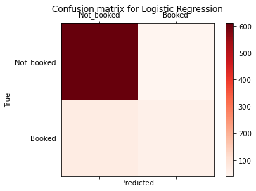

```python
%matplotlib inline

# Confusion matrix, accuracy, precison and recall for random forest and logistic regression
confusion_matrices = [
    ("Logistic Regression", confusion_matrix(model_test_y, best_LR_model.predict(model_test_x))),
    #("Logistic Regression", confusion_matrix(yc_test,best_LR_model.predict(Xc_test))),
]

draw_confusion_matrices(confusion_matrices)
```

#### ROC & AUC

```python
from sklearn.metrics import roc_curve
from sklearn import metrics

# Use predict_proba to get the probability results of Logistic Regression
y_pred_lr = best_LR_model.predict_proba(model_test_x)[:, 1]
fpr_lr, tpr_lr, _ = roc_curve(model_test_y, y_pred_lr)
```

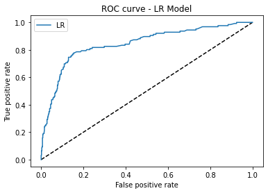

```python
# ROC Curve
plt.figure(1)
plt.plot([0, 1], [0, 1], 'k--')
plt.plot(fpr_lr, tpr_lr, label='LR')
plt.xlabel('False positive rate')
plt.ylabel('True positive rate')
plt.title('ROC curve - LR Model')
plt.legend(loc='best')
plt.show()
```

```python
# AUC score
metrics.auc(fpr_lr,tpr_lr)
```

```
0.8438278388278388
```

### Results interpretation

```python
# Store the coef for results interpretation
res = pd.DataFrame(columns=['Feature', 'Coef'])

for k,v in sorted(zip(map(lambda x: round(x, 4), best_LR_model.fit(model_train_x, model_train_y).coef_[0]), \
                      model_train_x.columns), key=lambda k_v:(-abs(k_v[0]),k_v[1])):
    print (v + ": " + str(k))
    res = res.append({'Feature': v, 'Coef': k}, ignore_index=True)
```

```
interactions_1-10: -1.7787
interactions_>30: 0.7136
interactions_1-10*days_of_stay_6-10d: -0.5966
interactions_21-30: 0.575
interactions_1-10*days_of_stay_1-5d: -0.5383
past_booker: 0.3844
reviews_0: -0.3809
days_of_stay_>15d: -0.3595
interactions_1-10*days_of_stay_>15d: -0.3445
interactions_1-10*days_of_stay_11-15d: -0.2993
interactions_21-30*days_of_stay_1-5d: 0.2454
interactions_>30*days_of_stay_6-10d: 0.2236
interactions_21-30*days_of_stay_6-10d: 0.223
interactions_>30*days_of_stay_1-5d: 0.2189
past_booker*interactions_>30: 0.2054
interactions_11-20*days_of_stay_>15d: -0.2039
interactions_11-20*days_of_stay_6-10d: 0.1819
past_booker*interactions_21-30: 0.1697
interactions_>30*days_of_stay_11-15d: 0.1601
days_of_stay_11-15d: -0.1429
interactions_11-20*days_of_stay_1-5d: 0.1418
past_booker*interactions_11-20: 0.137
past_booker*interactions_1-10: -0.1277
interactions_>30*days_of_stay_>15d: 0.1109
interactions_11-20: 0.0874
interactions_21-30*days_of_stay_>15d: 0.078
days_of_stay_1-5d: 0.0678
reviews_1-10: -0.0674
reviews_>30: 0.0662
interactions_11-20*days_of_stay_11-15d: -0.0324
days_of_stay_6-10d: 0.0319
accept_t: 0.0293
interactions_21-30*days_of_stay_11-15d: 0.0286
reviews_21-30: -0.0181
reviews_11-20: -0.0026
```

```python
res = res.set_index('Feature')
```

```python
print('past_booker: ' + str(res.Coef.loc['past_booker']))
print('accept_t: ' + str(res.Coef.loc['accept_t']))
```

```
past_booker: 0.3844
accept_t: 0.0293
```

Past bookers are more likely to confirm bookings after the inquiries are accepted

Longer accept time slightly increases the probability of confirmation

```python
for i in list(interactions):
  print(i + ": " + str(res.Coef.loc[i]))

for i in list(reviews):
  print(i + ": " + str(res.Coef.loc[i]))

for i in list(stays):
  print(i + ": " + str(res.Coef.loc[i]))
```

```
interactions_1-10: -1.7787
interactions_11-20: 0.0874
interactions_21-30: 0.575
interactions_>30: 0.7136
reviews_0: -0.3809
reviews_1-10: -0.0674
reviews_11-20: -0.0026
reviews_21-30: -0.0181
reviews_>30: 0.0662
days_of_stay_1-5d: 0.0678
days_of_stay_6-10d: 0.0319
days_of_stay_11-15d: -0.1429
days_of_stay_>15d: -0.3595
```

```python
for i in list(interactions):
  for j in list(stays):
    print(i + "*" + j + ": " + str(res.Coef.loc[i + "*" + j ]))
```

```
interactions_1-10*days_of_stay_1-5d: -0.5383
interactions_1-10*days_of_stay_6-10d: -0.5966
interactions_1-10*days_of_stay_11-15d: -0.2993
interactions_1-10*days_of_stay_>15d: -0.3445
interactions_11-20*days_of_stay_1-5d: 0.1418
interactions_11-20*days_of_stay_6-10d: 0.1819
interactions_11-20*days_of_stay_11-15d: -0.0324
interactions_11-20*days_of_stay_>15d: -0.2039
interactions_21-30*days_of_stay_1-5d: 0.2454
interactions_21-30*days_of_stay_6-10d: 0.223
interactions_21-30*days_of_stay_11-15d: 0.0286
interactions_21-30*days_of_stay_>15d: 0.078
interactions_>30*days_of_stay_1-5d: 0.2189
interactions_>30*days_of_stay_6-10d: 0.2236
interactions_>30*days_of_stay_11-15d: 0.1601
interactions_>30*days_of_stay_>15d: 0.1109
```

Having less than 10 interactions decreases the probability of confirmation for booking across all lengths of stay

Having more than 20 interactions increases the probability of confirmation for booking across all lengths of stay

```python
from google.colab import files

res.to_csv('mod3_res.csv')
files.download('mod3_res.csv')
```